# lecture-01-exercise-tokenization-25210980125-姚程缤

```python
from IPython.display import display, HTML

display(HTML("""
<style>
/* JupyterLab: center notebook and leave margins */
.jp-NotebookPanel-notebook {
  width: 85% !important;
  margin-left: auto !important;
  margin-right: auto !important;
  max-width: 1100px !important;       /* optional cap */
}

/* Make output area match nicely */
.jp-OutputArea {
  max-width: 100% !important;
}
</style>
"""))
# make high-resolution of images.
%config InlineBackend.figure_format = 'svg'
print("setup jnk layout and figure format.")
```

```
setup jnk layout and figure format.
```

- 0. Preparing Your Environment
  - 0.1 Install Anaconda and setup environment
  - 0.2 Checking your device
- 1. Explore LLMs via ollama
  - 1.1 Install ollama and download LLMs
  - 1.2 Get response for a given prompt
  - 1.3 Get response probability from LLMs
- 2. Basics for Python and spaCy
  - 2.1 Unicode for text data
  - 2.2 Python basics: regular expression
  - 2.3 (Old way) Tokenization tool: spaCy
- 3. Datasets Exploration
  - 3.1 Heap's Law
  - 3.2 Explore wikitext-2 dataset
  - 3.3 Explore wikitext-103 dataset
  - 3.4 BookCorpus datasets
- 4. LLMs tokenization (Modern Way)
  - 4.1 Subword tokenization: BPE
  - 4.2 Subword tokenization: WordPiece
  - 4.3 Subword tokenization: Unigram
- 5. Minimum Edit Distance
  - 5.1 Algorithm analysis
  - 5.2 Algorithm implementation
- 6. Submit Your Work
- 7. Useful Commands and References

## 0. Preparing Your Environment

### 0.1 Install Anaconda and setup environment

If you are using macOS or Linux, you are ready to go. **⚠️ If you are using Windows, I strongly recommend installing Ubuntu 22.04 via [WSL](https://ubuntu.com/desktop/wsl). In the rest of the instructions, I assume you are using Ubuntu/Linux or macOS.**

- **Step 1: Install Anaconda.** Download and install Anaconda from: https://www.anaconda.com/download.
- **Step 2: Setup your git.** Make sure you have [git](https://git-scm.com/install/) and ssh in your system (macOS usually already has both git and ssh). After the above step, you are ready to download our course github project. In your Ubuntu/Linux system, install git and sssh via

  `sudo apt update`

  `sudo apt install -y git openssh-client`

  Then, generate an SSH key (ed25519)

  `ssh-keygen -t ed25519 -C "your_email@example.com"`

  Press Enter for the default location, and optionally set a passphrase. This creates:
  - ~/.ssh/id_ed25519 (private key)
  - ~/.ssh/id_ed25519.pub (public key)

  Then, you can start ssh-agent and add the key:

  `eval "$(ssh-agent -s)"`

  `ssh-add ~/.ssh/id_ed25519`

  Add the public key to GitHub, that is, copy the generated key:

  `cat ~/.ssh/id_ed25519.pub`

  It will be something like, `ssh-ed25519 XXXXXXX...XXXXXXX your-email@xxx.com`. **Copy this line**, and then in GitHub: **Settings → SSH and GPG keys → New SSH key → paste.** To test the SSH connection, you can use `ssh -T git@github.com`, if it says something like “Hi USERNAME! …”, you’re good. After these steps, you are ready to clone our course github via

  `git clone git@github.com:baojian/llm-26.git`

  After the above steps, you are ready to create our course env.
- **Step 3: Create and activate the course environment.** Make sure you have installed the conda environment.
  - **Option 1:** If you have GPU in your machine (Linux + NVIDIA GPU), please create your env via

    `cd llm-26/lecture-01-tokenization/ # make sure your are in our course folder.`

    `conda env create -f environment-gpu.yml`

    Activate it with:

    `conda activate llm-26-gpu`

    Note: environment-gpu.yml uses `pytorch-cuda=12.1`. If your GPU driver/CUDA setup does not support CUDA 12.1, change this version accordingly (e.g., 11.8).
  - **Option 2:** If you use macOS / Windows (WSL) / Linux CPU-only, please create your env via

    `conda env create -f environment.yml`

    Activate it with:

    `conda activate llm-26-cpu`

    Note, if you got errors when installing `en_core_web_sm` or `zh_core_web_sm`, please remove these two from yml file and install separately in your env via

    ```
    conda activate llm-26 # or conda activate llm-26-gpu
    python -m spacy download en_core_web_sm
    python -m spacy download zh_core_web_sm
    ```

    After the above steps, you are ready to download our course github project.
- **Step 4: Open your jupyter notebook.**

  All your code will run on Jupyter notebook, you can activate jupyter notebook, via

  `cd llm-26 # make sure you are in our course folder`

  `conda activate llm-26-cpu # or conda activate llm-26-gpu`

  `jupyter lab`

  For students using Windows WSL (Ubuntu 22.04), even though Jupyter runs inside WSL (Ubuntu), you can open it directly in the Windows browser via port forwarding (usually automatic). In WSL Ubuntu, start Jupyter like this:

  `jupyter lab --no-browser --ip=127.0.0.1 --port=8888`

  It will print a URL like: `http://127.0.0.1:8888/lab?token=...`

  Now on Windows, open your browser and go to: `http://localhost:8888/lab` Paste the token if it asks. On WSL2, Windows automatically forwards localhost:8888 to the WSL instance in most setups. If localhost:8888 doesn’t work, in WSL run: `hostname -I`, suppose it prints something like 172.27.123.45 ..., then open in Windows: `http://172.27.123.45:8888/lab`
- **Load all necessary packages**

  At this point, your env is ready to use. We import all necessary packages here.

```python
import re
import os
import time
import math

import shutil
import socket
import platform
import requests
import datetime
import tarfile

import spacy
import torch
import numpy as np

from transformers import AutoTokenizer
from transformers import Qwen2Tokenizer, Qwen2TokenizerFast

import tiktoken
from tokenizers import normalizers
from tokenizers.normalizers import NFD, StripAccents
from tokenizers import decoders

from transformers import AutoTokenizer
from tokenizers import Tokenizer
from tokenizers import normalizers
from tokenizers.models import WordPiece
from tokenizers.normalizers import NFD, Lowercase, StripAccents
from tokenizers.pre_tokenizers import Whitespace
from tokenizers.processors import TemplateProcessing

from datasets import load_dataset
import matplotlib.pyplot as plt

jnk_start_time = time.time()
```

### 0.2 Checking your device

- After install conda and your env, you can check whether these packages are installed in the right way.

```
python -c "import torch; print('torch', torch.__version__); print('cuda?', torch.cuda.is_available()); print('mps?', getattr(torch.backends,'mps',None) is not None and torch.backends.mps.is_available()); print('cuda device:', torch.cuda.get_device_name(0) if torch.cuda.is_available() else 'no gpu'); print('using:', 'cuda' if torch.cuda.is_available() else ('mps' if (getattr(torch.backends,'mps',None) is not None and torch.backends.mps.is_available()) else 'cpu'))"
```

```python
!python -c "import torch; print('torch', torch.__version__); print('cuda?', torch.cuda.is_available()); print('mps?', getattr(torch.backends,'mps',None) is not None and torch.backends.mps.is_available()); print('cuda device:', torch.cuda.get_device_name(0) if torch.cuda.is_available() else 'no gpu'); print('using:', 'cuda' if torch.cuda.is_available() else ('mps' if (getattr(torch.backends,'mps',None) is not None and torch.backends.mps.is_available()) else 'cpu'))"
```

```
torch 2.5.1
cuda? True
mps? False
cuda device: NVIDIA GeForce RTX 2050
using: cuda
```

- The following code provides a more symmetric way to perform the same checks. In our lectures, some datasets are very large, so it’s a good idea to make sure you have enough disk space. You can check your disk, memory, and CPU information using the code below.

```python
def detect_torch_device(verbose: bool = True) -> str:
    """
    Returns one of: 'cuda', 'mps', 'cpu'
    Priority: CUDA GPU > Apple MPS > CPU
    """
    has_cuda = torch.cuda.is_available()
    has_mps = getattr(torch.backends, "mps", None) is not None and torch.backends.mps.is_available()

    if has_cuda:
        device = "cuda"
    elif has_mps:
        device = "mps"
    else:
        device = "cpu"

    if verbose:
        print(f"torch: {torch.__version__}")
        print(f"device: {device}")

        if has_cuda:
            print(f"cuda devices: {torch.cuda.device_count()}")
            for i in range(torch.cuda.device_count()):
                print(f"  [{i}] {torch.cuda.get_device_name(i)}")
        elif has_mps:
            print("mps available: True (Apple Metal)")
        else:
            print("cpu only")

    return device

device = detect_torch_device()
# generate 2x3 random matrix to check torch
x = torch.rand(2, 3)
x = x.to(device)
print("device:", x.device)
```

```
torch: 2.5.1
device: cuda
cuda devices: 1
  [0] NVIDIA GeForce RTX 2050
device: cuda:0
```

- **Exercise System Info Cell**

```python
def bytes_to_gb(x: int) -> float:
    return x / (1024 ** 3)

def system_report(path: str = "."):
    print("=== System Report ===")
    print("OS:", platform.system(), platform.release())
    print("Platform:", platform.platform())
    now = datetime.datetime.now().astimezone()
    print("Local time:", now.strftime("%Y-%m-%d %H:%M:%S %Z%z"))
    print("Hostname  :", socket.gethostname())
    print("User      :", os.getenv("USER") or os.getenv("USERNAME") or "unknown")

    print("\n=== OS / Python ===")
    print("OS        :", platform.system(), platform.release())
    print("Version   :", platform.version())
    print("Machine   :", platform.machine())
    print("Processor :", platform.processor() or "unknown")
    print("Python    :", platform.python_version())

    # CPU
    print("\n--- CPU ---")
    print("CPU cores (logical):", os.cpu_count())

    # Memory (best-effort, cross-platform)
    print("\n--- Memory (RAM) ---")
    try:
        import psutil  # you already have this in env
        vm = psutil.virtual_memory()
        print(f"Total: {bytes_to_gb(vm.total):.2f} GB")
        print(f"Available: {bytes_to_gb(vm.available):.2f} GB")
        print(f"Used: {bytes_to_gb(vm.used):.2f} GB ({vm.percent}%)")
    except Exception as e:
        print("psutil not available or failed:", e)

    # Disk
    print("\n--- Disk ---")
    total, used, free = shutil.disk_usage(path)
    print("Path checked:", os.path.abspath(path))
    print(f"Total: {bytes_to_gb(total):.2f} GB")
    print(f"Free:  {bytes_to_gb(free):.2f} GB")
    print(f"Used:  {bytes_to_gb(used):.2f} GB")

    # PyTorch device
    print("\n--- PyTorch Device ---")
    try:
        import torch
        cuda = torch.cuda.is_available()
        mps = hasattr(torch.backends, "mps") and torch.backends.mps.is_available()
        print("torch:", torch.__version__)
        print("CUDA available:", cuda)
        print("MPS available:", mps)
        if cuda:
            print("GPU:", torch.cuda.get_device_name(0))
        device = "cuda" if cuda else ("mps" if mps else "cpu")
        print("Suggested device:", device)
    except Exception as e:
        print("torch not available or failed:", e)

system_report(".")
```

```
=== System Report ===
OS: Windows 11
Platform: Windows-11-10.0.26200-SP0
Local time: 2026-03-07 15:39:31 中国标准时间+0800
Hostname  : Ciao-mainlaptop
User      : yaoch

=== OS / Python ===
OS        : Windows 11
Version   : 10.0.26200
Machine   : AMD64
Processor : Intel64 Family 6 Model 154 Stepping 3, GenuineIntel
Python    : 3.12.13

--- CPU ---
CPU cores (logical): 16

--- Memory (RAM) ---
Total: 15.73 GB
Available: 1.03 GB
Used: 14.70 GB (93.4%)

--- Disk ---
Path checked: e:\1FDU自然语言处理课程\llm-26\lecture-01-tokenization
Total: 465.75 GB
Free:  130.85 GB
Used:  334.90 GB

--- PyTorch Device ---
torch: 2.5.1
CUDA available: True
MPS available: False
GPU: NVIDIA GeForce RTX 2050
Suggested device: cuda
```

## 1. Explore LLMs via ollama

In this section, we’ll have some fun exploring LLMs with ollama.

### 1.1 Install ollama and download LLMs

We can download some popular LLMs such as Qwen series.

- **Step 1:** Please download and install ollama via download.
- **Step 2:** After the installation of ollama, you can open a terminal and download qwen3:0.6b and qwen3:1.7b via:

  `ollama run qwen3:0.6b`

  It will automatically download the model into your local disk. It takes about 498MB disk space. Similarly, you can run a larger version `qwen3:1.7b` and it takes about 1.3GB disk space. Let us test 0.6b model

  `ollama run qwen3:0.6b`
- **Step 2:** Ask a question, like: `hi, where is Fudan located at?`, it gives us:

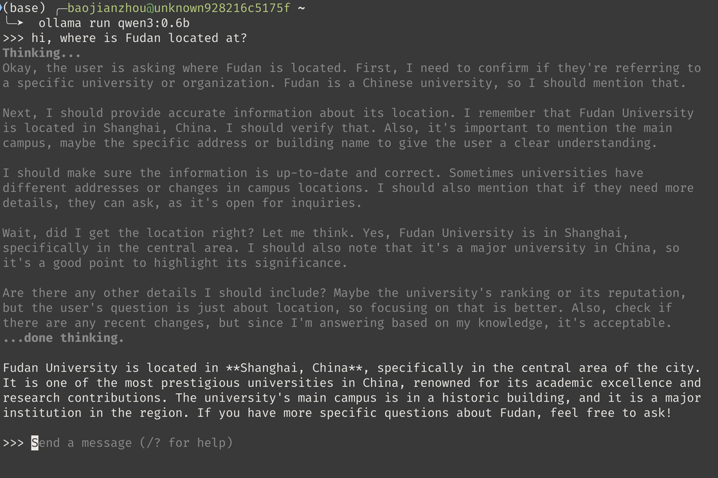

### 1.2 Get response for a given prompt

- **Call Ollama API**

  Next, we go a little deeper: we will call the Ollama API from Python to generate outputs given prompts. You can check whether Ollama is running by typing http://127.0.0.1:11434/ in Chrome.

```python
# Make sure bypass proxies for local services (e.g., Ollama on localhost:11434)
os.environ["OLLAMA_HOST"] = "http://127.0.0.1:11434"
os.environ["NO_PROXY"] = "localhost,127.0.0.1"
os.environ["no_proxy"] = "localhost,127.0.0.1"

s = requests.Session()
# IMPORTANT <- ignore ALL proxy env vars
s.trust_env = False
# make sure ollama is running
print(s.get("http://127.0.0.1:11434/api/version", timeout=3).json())

# !!!! make sure to import after the s.trust_env !!!!

import ollama
from ollama import chat
from ollama import ChatResponse

s = requests.Session()
s.trust_env = False  # <- ignore ALL proxy env vars

response: ChatResponse = chat(model='qwen3:0.6b', messages=[
  {
    'role': 'user',
    'content': 'Fudan University is located in which city? Answer with one word.',
  },
])
print(response['message']['content'])
```

```
{'version': '0.17.6'}
Shanghai
```

- **Will the same prompt always produce the same output?**

```python
models = ["qwen3:0.6b", "qwen3:1.7b"]
prompt = "Fudan University is located in which city? Answer with one word."

for model in models:
    print('-' * 50)
    start_time = time.time()
    for _ in range(10):
        resp = ollama.generate(
            model = model,
            prompt = prompt
        )
        print(f"{model} with resp {_ + 1}: {resp["response"]}")
    print(f'total runtime of 10 responses of {model} is: {time.time() - start_time:.1f} seconds')
```

```
--------------------------------------------------
qwen3:0.6b with resp 1: Hangzhou
qwen3:0.6b with resp 2: Hangzhou
qwen3:0.6b with resp 3: Shenzhen
qwen3:0.6b with resp 4: Shanghai
qwen3:0.6b with resp 5: Hangzhou
qwen3:0.6b with resp 6: Shanghai
qwen3:0.6b with resp 7: Shanghai
qwen3:0.6b with resp 8: Shanghai
qwen3:0.6b with resp 9: Hangzhou
qwen3:0.6b with resp 10: Shanghai
total runtime of 10 responses of qwen3:0.6b is: 11.0 seconds
--------------------------------------------------
qwen3:1.7b with resp 1: Shanghai
qwen3:1.7b with resp 2: Shanghai
qwen3:1.7b with resp 3: Shanghai
qwen3:1.7b with resp 4: Shanghai
qwen3:1.7b with resp 5: Shanghai
qwen3:1.7b with resp 6: Shanghai
qwen3:1.7b with resp 7: Shanghai
qwen3:1.7b with resp 8: Shanghai
qwen3:1.7b with resp 9: Shanghai
qwen3:1.7b with resp 10: Shanghai
total runtime of 10 responses of qwen3:1.7b is: 32.2 seconds
```

- **Some key observations**:
  - The smaller model, **Qwen3:0.6B**, tends to produce lower-quality answers, while the larger model, **Qwen3:1.7B**, generally produces higher-quality answers.
  - The **responses are somewhat random**: running the same prompt multiple times may yield different outputs. There are ways to make the output deterministic. For example, the code below sets decoding options so that the model always selects the highest-probability token at each step.

    ```python
            resp = ollama.generate(
            model=model,
            prompt=prompt,
            options={
                "temperature": 0.0,
                "top_p": 1.0,
                "top_k": 0,
                # optional:
                "num_predict": 32,
            },
            )
            print(resp["response"])
    ```

  Let us generate some response that are not one word but a sequence of words.
- **Get a paragraph of response with qwen3:1.7b**

```python
model = "qwen3:1.7b"
prompt = "I am an undergraduate student, please explain LLMs in three sentences."
resp = ollama.generate(
            model=model,
            prompt=prompt
        )
print(f"Prompt: {prompt} \nResp: {resp["response"]}")
```

```
Prompt: I am an undergraduate student, please explain LLMs in three sentences.
Resp: Large Language Models (LLMs) are AI systems trained on vast text datasets to understand and generate human-like text. They use deep learning techniques to analyze patterns and context, enabling tasks like writing, coding, or answering questions. LLMs rely on neural networks to adapt their resp…
```

### 1.3 Get response probability from LLMs

- **Get token probability (Observe: single word could be tokenized into subwords.)**

```python
model = "qwen3:0.6b" # "qwen3:1.7b"
prompt = "Fudan University is located in which city? Answer with one word."
num_top_tokens = 20 # number of top alternatives per generated token
resp = ollama.generate(
    model = model,
    prompt = prompt,
    stream = False,
    logprobs = True,
    think = False,
    top_logprobs = num_top_tokens
)
print("response:", repr(resp["response"]))

# Each element usually corresponds to one generated token
for i, lp in enumerate(resp.get("logprobs", [])):
    tok = lp.get("token")
    logp = lp.get("logprob")
    p = math.exp(logp) if logp is not None else None
    print(f"{i:02d} token={tok!r:>16} logp={logp: .4f} p={p:.4f}")
```

```
response: 'Fudan University is located in **Fudan City**.'
00 token=             'F' logp=-0.8758 p=0.4165
01 token=            'ud' logp=-0.0000 p=1.0000
02 token=            'an' logp=-0.0001 p=0.9999
03 token=   ' University' logp=-0.0274 p=0.9730
04 token=           ' is' logp=-0.0283 p=0.9721
05 token=      ' located' logp=-0.0005 p=0.9995
06 token=           ' in' logp=-0.0006 p=0.9994
07 token=           ' **' logp=-0.5863 p=0.5564
08 token=             'F' logp=-1.8755 p=0.1533
09 token=            'ud' logp=-0.0643 p=0.9377
10 token=            'an' logp=-0.0008 p=0.9992
11 token=         ' City' logp=-0.7341 p=0.4799
12 token=            '**' logp=-0.0734 p=0.9293
13 token=             '.' logp=-0.0057 p=0.9944
```

- **Get specific token probability distribution via logprobs (without thinking)**

```python
model = "qwen3:0.6b"
prompt = "Fudan University is located in which city? Answer with one word."

res = ollama.generate(
    model=model,
    prompt=prompt,
    logprobs=True,
    think = False,
    top_logprobs=10,
    options={"temperature": 0.0, # greedy decoding, it pick the maximal token
             "num_predict": 20,
            "think": False # do not use thinking model.
            },
)

answer = ''
# lp 是一个列表，每个元素包含当前生成的 token、它的 logprob 以及 top_logprobs 候选列表
lp = res["logprobs"]
tokens = [d.get("token", "") for d in lp]
print(f'We use model: {model}')
for i in range(len(lp)):
    tok = lp[i].get("token", "")
    logp = lp[i].get("logprob", None)
    alts = lp[i].get("top_logprobs", [])
    p = math.exp(logp) if logp is not None else float("nan")
    if tok == "\n" or tok == "\n\n": # stop when answer ends (often newline).
        break
    answer += tok
    print(f"--- top probabilities of token-{i:02d} ---")
    for a in alts[:20]:
        prob_a = math.exp(a['logprob'])
        print(f"{a['token']!r:>12}:{prob_a:.5f}")
    print(f"\nPartial Response: {answer}\n")
print(f"Final Response: {answer}")
```

```
We use model: qwen3:0.6b
--- top probabilities of token-00 ---
         'F':0.37669
        'Be':0.29270
        'Sh':0.15878
        'Ch':0.05192
        'Gu':0.03733
         'H':0.02195
         'S':0.01018
         'J':0.00587
         'Y':0.00526
         'X':0.00395

Partial Response: F

--- top probabilities of token-01 ---
        'ud':0.99995
     'uding':0.00002
        'UD':0.00001
       'udu':0.00001
       'ude':0.00000
       'ush':0.00000
        'uz':0.00000
      'uden':0.00000
       'udo':0.00000
        'us':0.00000

Partial Response: Fud

--- top probabilities of token-02 ---
        'an':0.99990
       'ian':0.00006
        'ai':0.00001
        'un':0.00001
       'ans':0.00000
       'uan':0.00000
       'ang':0.00000
        'ay':0.00000
       'anz':0.00000
       'ant':0.00000
```

[output cut: 115 more lines]

```
--- top probabilities of token-11 ---
         '.':0.99968
        ' (':0.00018
     ' city':0.00008
     '.\n\n':0.00002
         ',':0.00001
     ' City':0.00001
       '.\n':0.00001
       ' in':0.00001
       ' ��':0.00000
    ' China':0.00000

Partial Response: Fudan University is located in **Shanghai**.

Final Response: Fudan University is located in **Shanghai**.
```

```python
lp[1]
```

```
Logprob(token='ud', logprob=-5.2978346502641216e-05, top_logprobs=[TokenLogprob(token='ud', logprob=-5.2978346502641216e-05), TokenLogprob(token='uding', logprob=-10.761032104492188), TokenLogprob(token='UD', logprob=-11.685222625732422), TokenLogprob(token='udu', logprob=-12.14200210571289), TokenL…
```

- **LLMs are probabilitic distributions**

From the outputs above, you can see that the response from these LLMs may differ from run to run. In fact, LLMs are **probabilistic models**: given the same prompt (i.e., question), they may produce different responses (i.e., answers). We can describe this inference process using mathematical notation. Let $p_\theta(\cdot)$ denote a trained language model. Here, you can think of $p_\theta$ as **Qwen3:0.6B**, **Qwen3:1.7B**, or any other model. Given the following prompt

> Prompt = Fudan University is located in which city? Answer with one word.

**This prompt is a sequence of tokens**. The model outputs a response, which is also a sequence of tokens. In other words, the model uses an inference procedure to predict the next token(s) conditioned on the prompt. In math, it models the conditional probability

> $$p_\theta \left(w_{n+1} \mid w_1,w_2,\ldots,w_n\right),$$

where

- **Prompt**$[w_1,w_2,\ldots,w_n]$ =[ Fudan University is located in which city? Answer with one word. ],
- **Response** = $[w_{n+1}]$ (in this simplified one-word setting).

The model then outputs the most likely token $w_{n+1}$ (or samples from the distribution) using its own inference algorithm. We will discuss inference strategies in later lectures. By the definition of conditional probability, we have

> $$ p_\theta \left(w_{n+1} \mid w_1,w_2,\ldots,w_n\right) = \frac{ p_\theta \left(w_1,w_2,\ldots,w_n,w_{n+1}\right) }{ p_\theta \left(w_1,w_2,\ldots,w_n\right) }. $$

The key takeaway is: **if we can learn a model that assigns probabilities to sequences of arbitrary length**, i.e., $p_\theta(w_1,w_2,\ldots,w_k)$ for any positive integer $k$, then conditional probabilities follow naturally from these joint probabilities. Let us do one more example to see when the response is more than one word.

- **Get a sequence of token probabilities from Qwen3:1.7b**

```python
model = "qwen3:1.7b"
prompt = "Fudan University is located in which city? Answer with one word."

res = ollama.generate(
    model=model,
    prompt=prompt,
    logprobs=True,# 返回每个生成 token 的 log probability（对数概率）
    think = False,
    top_logprobs=10,
    options={"temperature": 0.0, # greedy decoding, it pick the maximal token
             "num_predict": 20,
            "think": False # do not use thinking model.
            },
)
print(res["response"])
```

```
Fudan University is located in **Shanghai**.
```

- If we do not use thinking mode, it gives the above response. However, we can still see how the token *Shanghai* is chosen during the inference stage. You will see these subword tokens have high probabilities.

```python
model = "qwen3:1.7b"
prompt = "Fudan University is located in which city? Answer with one word."
print(f'We use model: {model}')

res = ollama.generate(
    model=model,
    prompt=prompt,
    logprobs=True,
    think = False, # Do not use the thinking model.
    top_logprobs=10,
    options={"temperature": 0.0, # greedy decoding, it pick the maximal token
             "num_predict": 20,
            "think": False # do not use thinking model.
            },
)

answer = ''
lp = res["logprobs"]
tokens = [d.get("token", "") for d in lp]
for i in range(len(lp)):
    tok = lp[i].get("token", "")
    logp = lp[i].get("logprob", None)
    alts = lp[i].get("top_logprobs", [])
    p = math.exp(logp) if logp is not None else float("nan")
    # stop when answer ends (often newline).
    if tok == "\n" or tok == "\n\n":
        break
    answer += tok
    print(f"--- top probabilities of token-{i:02d} ---")
    for a in alts[:5]:
        prob_a = math.exp(a['logprob'])
        print(f"{a['token']!r:>5}:{prob_a:.5f}", end="")
    print(f"\nPartial Response: {answer}\n")
print(f"Final Response: {answer}")
```

```
We use model: qwen3:1.7b
--- top probabilities of token-00 ---
  'F':0.99942 'An':0.00031 'Sh':0.00013 'Fu':0.00011  'Z':0.00001
Partial Response: F

--- top probabilities of token-01 ---
 'ud':0.99998 'uj':0.00001 'uz':0.00000'uding':0.00000 'uy':0.00000
Partial Response: Fud

--- top probabilities of token-02 ---
 'an':1.00000'ans':0.00000 'am':0.00000 'ан':0.00000'anian':0.00000
Partial Response: Fudan

--- top probabilities of token-03 ---
' University':1.00000'University':0.00000' Univers':0.00000' Univ':0.00000' Universe':0.00000
Partial Response: Fudan University

--- top probabilities of token-04 ---
' is':1.00000'是中国':0.00000  '是':0.00000' adalah':0.00000' là':0.00000
Partial Response: Fudan University is

--- top probabilities of token-05 ---
' located':1.00000' Located':0.00000 '位于':0.00000' situated':0.00000'located':0.00000
Partial Response: Fudan University is located

--- top probabilities of token-06 ---
' in':1.00000  '在':0.00000 ' в':0.00000' في':0.00000' on':0.00000
Partial Response: Fudan University is located in

--- top probabilities of token-07 ---
' **':1.00000' Shanghai':0.00000' __':0.00000 ' *':0.00000' ______':0.00000
Partial Response: Fudan University is located in **

--- top probabilities of token-08 ---
 'Sh':0.65558  'W':0.16091  'F':0.15125  'P':0.01632  'N':0.00662
Partial Response: Fudan University is located in **Sh

--- top probabilities of token-09 ---
'anghai':0.99936'ang':0.00060'enzhen':0.00002 'en':0.00001'eng':0.00000
Partial Response: Fudan University is located in **Shanghai

--- top probabilities of token-10 ---
 '**':1.00000'**,':0.00000'***':0.00000'**:':0.00000' City':0.00000
Partial Response: Fudan University is located in **Shanghai**

--- top probabilities of token-11 ---
  '.':1.00000'.\n\n':0.00000'.\n':0.00000  '．':0.00000'.\n\n\n':0.00000
Partial Response: Fudan University is located in **Shanghai**.

Final Response: Fudan University is located in **Shanghai**.
```

Above response process is essentially next-token prediction task as qwen3:1.7b is an AR model!

## 2. Basics for Python and spaCy

- **Python**: We will use Python-3.12 in our course.
- **spaCy**: As introduced in https://github.com/explosion/spaCy, [spaCy](https://spacy.io/) is a library for advanced Natural Language Processing in Python and Cython. It's built on the very latest research, and was designed from day one to be used in real products. We will use it to demonostrate how to do text tokenization.
- **nltk tool (outdated, will not cover in our lectures)**: In our previous courses, we usually introduce https://github.com/nltk/nltk tool for tokenization stuff. But we will not cover this part as these tools are largely iirelvant and outdated.

```python
# packages needed in this section
import re
import os
import spacy
import numpy as np
import matplotlib.pyplot as plt
```

### 2.1 Unicode for text data

- **Encoding Strings to Bytes**

  Use the *.encode()* method on a string object to convert it into a bytes object using UTF-8.

```python
my_string = "Hello, World! 你好，世界！"
encoded_bytes = my_string.encode('utf-8') # Encode the string to UTF-8 bytes
print(encoded_bytes)
```

```
b'Hello, World! \xe4\xbd\xa0\xe5\xa5\xbd\xef\xbc\x8c\xe4\xb8\x96\xe7\x95\x8c\xef\xbc\x81'
```

- **Decoding Bytes to Strings**

  Use the *.decode()* method on a bytes object to convert it back into a string, specifying the encoding used to generate the bytes.

```python
encoded_bytes = b'Hello, World! \xe4\xbd\xa0\xe5\xa5\xbd\xef\xbc\x8c\xe4\xb8\x96\xe7\x95\x8c\xef\xbc\x81'
decoded_string = encoded_bytes.decode('utf-8') # Decode the bytes back to a string
print(decoded_string)
```

```
Hello, World! 你好，世界！
```

- **Write and Read utf-8 text into/from files**

```python
with open('unicode_file.txt', 'w', encoding='utf-8') as f:
    f.write("Some text with a special character: é, 你好，世界！")

with open('unicode_file.txt', 'r', encoding='utf-8') as f:
    content = f.read()
    print(content)
```

```
Some text with a special character: é, 你好，世界！
```

- **ASCII (American Standard Code for Information Interchange)**.

  ASCII represented each character with a single byte in the unicode. UTF-8 is a variable-length encoding format. In Python 3, UTF-8 is the default encoding for source files, strings, and many operations

```python
import pandas as pd

rows = []
for dec in range(128):
    ch = chr(dec)
    ch_disp = repr(ch)[1:-1] if (dec < 32 or dec == 127) else ch
    rows.append({"Ch": ch_disp, "Hex": f"{dec:02X}", "Dec": dec}) #ch是character, hex是十六进制，dec是十进制
df = pd.DataFrame(rows)
df
```

|  | Ch | Hex | Dec |
| --- | --- | --- | --- |
| 0 | \x00 | 00 | 0 |
| 1 | \x01 | 01 | 1 |
| 2 | \x02 | 02 | 2 |
| 3 | \x03 | 03 | 3 |
| 4 | \x04 | 04 | 4 |
| ... | ... | ... | ... |
| 123 | { | 7B | 123 |
| 124 | \| | 7C | 124 |
| 125 | } | 7D | 125 |
| 126 | ~ | 7E | 126 |
| 127 | \x7f | 7F | 127 |

128 rows × 3 columns

```python
nblocks = 8
chunk = (len(df) + nblocks - 1) // nblocks  # ceil实现向上取整

blocks = []
for i in range(nblocks):
    part = df.iloc[i * chunk : (i + 1) * chunk].reset_index(drop=True)
    part.columns = pd.MultiIndex.from_product([[f"Block {i+1}"], part.columns])
    blocks.append(part)

len(blocks)
```

```
8
```

```python
df3 = pd.concat(blocks, axis=1)
sty = (
    df3.style
      .set_properties(**{"text-align": "center"})
      .set_table_styles([
          {"selector": "th.col_heading.level0", "props": [("text-align", "center")]},
          {"selector": "th, td", "props": [("border", "1px solid #bbb"), ("padding", "2px 6px")]},
          {"selector": "table", "props": [("border-collapse", "collapse")]},
      ])
)
sty
```

|  | Block 1 Ch | Block 1 Hex | Block 1 Dec | Block 2 Ch | Block 2 Hex | Block 2 Dec | Block 3 Ch | Block 3 Hex | Block 3 Dec | Block 4 Ch | Block 4 Hex | Block 4 Dec | Block 5 Ch | Block 5 Hex | Block 5 Dec | Block 6 Ch | Block 6 Hex | Block 6 Dec | Block 7 Ch | Block 7 Hex | Block 7 Dec | Block 8 Ch | Block 8 Hex | Block 8 Dec |
| --- | --- | --- | --- | --- | --- | --- | --- | --- | --- | --- | --- | --- | --- | --- | --- | --- | --- | --- | --- | --- | --- | --- | --- | --- |
| 0 | \x00 | 00 | 0 | \x10 | 10 | 16 |  | 20 | 32 | 0 | 30 | 48 | @ | 40 | 64 | P | 50 | 80 | ` | 60 | 96 | p | 70 | 112 |
| 1 | \x01 | 01 | 1 | \x11 | 11 | 17 | ! | 21 | 33 | 1 | 31 | 49 | A | 41 | 65 | Q | 51 | 81 | a | 61 | 97 | q | 71 | 113 |
| 2 | \x02 | 02 | 2 | \x12 | 12 | 18 | " | 22 | 34 | 2 | 32 | 50 | B | 42 | 66 | R | 52 | 82 | b | 62 | 98 | r | 72 | 114 |
| 3 | \x03 | 03 | 3 | \x13 | 13 | 19 | # | 23 | 35 | 3 | 33 | 51 | C | 43 | 67 | S | 53 | 83 | c | 63 | 99 | s | 73 | 115 |
| 4 | \x04 | 04 | 4 | \x14 | 14 | 20 | $ | 24 | 36 | 4 | 34 | 52 | D | 44 | 68 | T | 54 | 84 | d | 64 | 100 | t | 74 | 116 |
| 5 | \x05 | 05 | 5 | \x15 | 15 | 21 | % | 25 | 37 | 5 | 35 | 53 | E | 45 | 69 | U | 55 | 85 | e | 65 | 101 | u | 75 | 117 |
| 6 | \x06 | 06 | 6 | \x16 | 16 | 22 | & | 26 | 38 | 6 | 36 | 54 | F | 46 | 70 | V | 56 | 86 | f | 66 | 102 | v | 76 | 118 |
| 7 | \x07 | 07 | 7 | \x17 | 17 | 23 | ' | 27 | 39 | 7 | 37 | 55 | G | 47 | 71 | W | 57 | 87 | g | 67 | 103 | w | 77 | 119 |
| 8 | \x08 | 08 | 8 | \x18 | 18 | 24 | ( | 28 | 40 | 8 | 38 | 56 | H | 48 | 72 | X | 58 | 88 | h | 68 | 104 | x | 78 | 120 |
| 9 | \t | 09 | 9 | \x19 | 19 | 25 | ) | 29 | 41 | 9 | 39 | 57 | I | 49 | 73 | Y | 59 | 89 | i | 69 | 105 | y | 79 | 121 |
| 10 | \n | 0A | 10 | \x1a | 1A | 26 | * | 2A | 42 | : | 3A | 58 | J | 4A | 74 | Z | 5A | 90 | j | 6A | 106 | z | 7A | 122 |
| 11 | \x0b | 0B | 11 | \x1b | 1B | 27 | + | 2B | 43 | ; | 3B | 59 | K | 4B | 75 | [ | 5B | 91 | k | 6B | 107 | { | 7B | 123 |
| 12 | \x0c | 0C | 12 | \x1c | 1C | 28 | , | 2C | 44 | < | 3C | 60 | L | 4C | 76 | \ | 5C | 92 | l | 6C | 108 | \| | 7C | 124 |
| 13 | \r | 0D | 13 | \x1d | 1D | 29 | - | 2D | 45 | = | 3D | 61 | M | 4D | 77 | ] | 5D | 93 | m | 6D | 109 | } | 7D | 125 |
| 14 | \x0e | 0E | 14 | \x1e | 1E | 30 | . | 2E | 46 | > | 3E | 62 | N | 4E | 78 | ^ | 5E | 94 | n | 6E | 110 | ~ | 7E | 126 |
| 15 | \x0f | 0F | 15 | \x1f | 1F | 31 | / | 2F | 47 | ? | 3F | 63 | O | 4F | 79 | _ | 5F | 95 | o | 6F | 111 | \x7f | 7F | 127 |

```python
my_string = "Hello, World! अनुच्छेद, 你好，世界！"

encodings = ["utf-8", "utf-16-le", "gb18030"] # diiferent encoding method
print("\nEncoded bytes (hex):")
for enc in encodings:
    b = my_string.encode(enc)
    print(f"{enc:9s}  {b.hex(' ')}")

# 3) Per-character UTF-8 bytes (useful for teaching)
print("\nPer-Char      Code-Point   UTF-8-Bytes")
for ch in my_string:
    b = ch.encode("utf-8")
    print(f"{repr(ch):>6}    ->    U+{ord(ch):04X}    ->    {b.hex(' ')}")
```

```
Encoded bytes (hex):
utf-8      48 65 6c 6c 6f 2c 20 57 6f 72 6c 64 21 20 e0 a4 85 e0 a4 a8 e0 a5 81 e0 a4 9a e0 a5 8d e0 a4 9b e0 a5 87 e0 a4 a6 2c 20 e4 bd a0 e5 a5 bd ef bc 8c e4 b8 96 e7 95 8c ef bc 81
utf-16-le  48 00 65 00 6c 00 6c 00 6f 00 2c 00 20 00 57 00 6f 00 72 00 6c 00 64 00 21 00 20 00 05 09 28 09 41 09 1a 09 4d 09 1b 09 47 09 26 09 2c 00 20 00 60 4f 7d 59 0c ff 16 4e 4c 75 01 ff
gb18030    48 65 6c 6c 6f 2c 20 57 6f 72 6c 64 21 20 81 31 cd 33 81 31 d0 38 81 31 d3 33 81 31 cf 34 81 31 d4 35 81 31 cf 35 81 31 d3 39 81 31 d0 36 2c 20 c4 e3 ba c3 a3 ac ca c0 bd e7 a3 a1

Per-Char      Code-Point   UTF-8-Bytes
   'H'    ->    U+0048    ->    48
   'e'    ->    U+0065    ->    65
   'l'    ->    U+006C    ->    6c
   'l'    ->    U+006C    ->    6c
   'o'    ->    U+006F    ->    6f
   ','    ->    U+002C    ->    2c
   ' '    ->    U+0020    ->    20
   'W'    ->    U+0057    ->    57
   'o'    ->    U+006F    ->    6f
   'r'    ->    U+0072    ->    72
   'l'    ->    U+006C    ->    6c
   'd'    ->    U+0064    ->    64
   '!'    ->    U+0021    ->    21
   ' '    ->    U+0020    ->    20
   'अ'    ->    U+0905    ->    e0 a4 85
   'न'    ->    U+0928    ->    e0 a4 a8
   'ु'    ->    U+0941    ->    e0 a5 81
   'च'    ->    U+091A    ->    e0 a4 9a
   '्'    ->    U+094D    ->    e0 a5 8d
   'छ'    ->    U+091B    ->    e0 a4 9b
   'े'    ->    U+0947    ->    e0 a5 87
   'द'    ->    U+0926    ->    e0 a4 a6
   ','    ->    U+002C    ->    2c
   ' '    ->    U+0020    ->    20
   '你'    ->    U+4F60    ->    e4 bd a0
   '好'    ->    U+597D    ->    e5 a5 bd
   '，'    ->    U+FF0C    ->    ef bc 8c
   '世'    ->    U+4E16    ->    e4 b8 96
   '界'    ->    U+754C    ->    e7 95 8c
   '！'    ->    U+FF01    ->    ef bc 81
```

### 2.2 Python basics: regular expression

- **Disjunction []**

```python
# Task: Find woodchuck or Woodchuck : Disjunction

test_str = "This string contains Woodchuck and woodchuck."

result=re.search(pattern="[wW]oodchuck", string=test_str)
print("Matched" if result is not None else "Not found")
result=re.search(pattern=r"[wW]ooodchuck", string=test_str)
print("Matched" if result is not None else "Not found")
```

```
Matched
Not found
```

```python
# Find the word "woodchuck" in the following test string

test_str = "interesting links to woodchucks ! and lemurs!"
result = re.search(pattern="woodchuck", string=test_str)
print("Matched" if result is not None else "Not found")
```

```
Matched
```

```python
# Find !, it follows the same way:

test_str = "interesting links to woodchucks ! and lemurs!"
# test_str = "Wow!! This has double exclamation."

result = re.search(pattern="!", string=test_str)
print("Matched" if result is not None else "Not found")
result = re.search(pattern="!!", string=test_str)
print("Matched" if result is not None else "Not found")
assert re.search(pattern="!!", string=test_str) == None # match nothing
```

```
Matched
Not found
```

- **Disjunction any digit [0-9]**

```python
# Find any single digit in a string.
#罗列所有数字
result=re.search(pattern=r"[0123456789]", string="plenty of 7 to 5")
print("Matched" if result is not None else "Not found", result)
#使用连字符范围（推荐）
result=re.search(pattern=r"[0-9]", string="plenty of 7 to 5")
print("Matched" if result is not None else "Not found", result)
```

```
Matched <re.Match object; span=(10, 11), match='7'>
Matched <re.Match object; span=(10, 11), match='7'>
```

- **Negation:[^**

```python
# Negation: If the caret ^ is the first symbol after [,
# the resulting pattern is negated. For example, the pattern
# [^a] matches any single character (including special characters) except a.
# 否定：如果插入符号 ^ 是紧跟在 [ 之后的第一个符号，
# 则生成的模式表示“非”（取反）。例如，模式 [^a] 匹配除 'a' 以外的任何单个字符（包括特殊字符）。
# -- not an upper case letter
print(re.search(pattern=r"[^A-Z]", string="Oyfn pripetchik"))
# -- neither 'S' nor 's'
print(re.search(pattern=r"[^Ss]", string="I have no exquisite reason for't"))
# -- not a period
print(re.search(pattern=r"[^.]", string="our resident Djinn"))
# -- either 'e' or '^'
print(re.search(pattern=r"[e^]", string="look up ^ now"))
# -- the pattern ‘a^b’
print(re.search(pattern=r'a\^b', string=r'look up a^b now'))
```

```
<re.Match object; span=(1, 2), match='y'>
<re.Match object; span=(0, 1), match='I'>
<re.Match object; span=(0, 1), match='o'>
<re.Match object; span=(8, 9), match='^'>
<re.Match object; span=(8, 11), match='a^b'>
```

- **Or Operation: |**

```python
# More disjuncations with or or operation
str1 = "Woodchucks is another name for groundhog!"
result = re.search(pattern="groundhog|woodchuck",string=str1)
print(result)
```

```
<re.Match object; span=(31, 40), match='groundhog'>
```

```python
str1 = "Find all woodchuckk Woodchuck Groundhog groundhogxxx!"
result = re.findall(pattern="[gG]roundhog|[Ww]oodchuck",string=str1)
print(result)
```

```
['woodchuck', 'Woodchuck', 'Groundhog', 'groundhog']
```

- **Special Operations: ?,*,+,.,$**

```python
# Some special chars

# ?: Optional previous char
str1 = "Find all color colour colouur colouuur colouyr"
result = re.findall(pattern="colou?r",string=str1)
print(result)

# *: 0 or more of previous char
str1 = "Find all color colour colouur colouuur colouyr"
result = re.findall(pattern="colou*r",string=str1)
print(result)

# +: 1 or more of previous char
str1 = "baa baaa baaaa baaaaa"
result = re.findall(pattern="baa+",string=str1)
print(result)
# .: any char
str1 = "begin begun begun beg3n"
result = re.findall(pattern="beg.n",string=str1)
print(result)
str1 = "The end."
result = re.findall(pattern=r"\.$",string=str1)
print(result)
str1 = "The end? The end. #t"
result = re.findall(pattern=r".$",string=str1)
print(result)
```

```
['color', 'colour']
['color', 'colour', 'colouur', 'colouuur']
['baa', 'baaa', 'baaaa', 'baaaaa']
['begin', 'begun', 'begun', 'beg3n']
['.']
['t']
```

```python
# find all "the" in a raw text use above operations.

text = "If two sequences in an alignment share a common ancestor, \
mismatches can be interpreted as point mutations and gaps as indels (that \
is, insertion or deletion mutations) introduced in one or both lineages in \
the time since they diverged from one another. In sequence alignments of \
proteins, the degree of similarity between amino acids occupying a \
particular position in the sequence can be interpreted as a rough \
measure of how conserved a particular region or sequence motif is \
among lineages. The absence of substitutions, or the presence of \
only very conservative substitutions (that is, the substitution of \
amino acids whose side chains have similar biochemical properties) in \
a particular region of the sequence, suggest [3] that this region has \
structural or functional importance. Although DNA and RNA nucleotide bases \
are more similar to each other than are amino acids, the conservation of \
base pairs can indicate a similar functional or structural role."
matches = re.findall("[^a-zA-Z][tT]he[^a-zA-Z]", text)
print(matches)
```

```
[' the ', ' the ', ' the ', ' The ', ' the ', ' the ', ' the ', ' the ']
```

```python
# Above has spaces before or after each word. A nicer way is to do the following
matches = re.findall(r"\b[tT]he\b", text)
print(matches)
```

```
['the', 'the', 'the', 'The', 'the', 'the', 'the', 'the']
```

- **Real-world task: match English-like words [A-Za-z]+(?:'[A-Za-z]+)?**

  You can decompose this task into:
  - [A-Za-z]+: Match one or more letters (A–Z or a–z). Examples: cat, PlayStation, Media
  - (?:...): A non-capturing group (grouping for structure, but findall won’t return it separately).
  - [A-Za-z]+: inside the group, Match a literal apostrophe (撇号) ' followed by one or more letters. Examples matched as a whole word: don't, I'm, teacher's
  - ?: after the group, Makes the apostrophe+letters part optional (0 or 1 time).
  - So it matches:
    - ✅ we, Valkyria, PlayStation, don't, teacher's
    - ❌ numbers (2011), hyphenated tokens (real-time), non-ASCII letters (Senjō → only Senj), punctuation, @-@, etc.

```python
word_re = re.compile(r"[A-Za-z]+(?:'[A-Za-z]+)?")

text = """don't Senjō no Valkyria 3 : Unrecorded Chronicles ( Japanese : 戦場のヴァルキュリア3 ,\
lit . Valkyria of the Battlefield 3 ) , commonly referred to as Valkyria Chronicles \
III outside Japan , is a tactical role @-@ playing video game developed by Sega and \
Media.Vision for the PlayStation Portable . Released in January 2011 in Japan , \
it is the third game in the Valkyria series . Employing the same fusion of tactical \
and real @-@ time gameplay as its predecessors"""

tokens = word_re.findall(text)
print(len(tokens))
print(tokens)
```

```
65
["don't", 'Senj', 'no', 'Valkyria', 'Unrecorded', 'Chronicles', 'Japanese', 'lit', 'Valkyria', 'of', 'the', 'Battlefield', 'commonly', 'referred', 'to', 'as', 'Valkyria', 'Chronicles', 'III', 'outside', 'Japan', 'is', 'a', 'tactical', 'role', 'playing', 'video', 'game', 'developed', 'by', 'Sega', 'a…
```

### 2.3 Tokenization using spaCy (Old way)

Usually, there are two type of tokenizations:

- **Top-down tokenization (classic)**: We define a standard and implement rules to implement that kind of tokenization.
  - word tokenization (spaCy, nltk)
  - charater tokenization (also can be done via spaCy)
- **Bottom-up tokenization (modern)**: We use simple statistics of letter sequences to break up words into subword tokens.
  - subword tokenization (modern LLMs use this type!)

**Tokenization via spaCy.** We assume you already installed spaCy tool. If you haven't installed yet, open your terminal and activate your llm-26 env, and then run the following to download English and Chinese LMs.

`python -m spacy download en_core_web_sm`

`python -m spacy download zh_core_web_sm`

- **Top-down (rule-based) word tokenization: Tokenization via white space**

```python
# Use split method via the whitespace " "
text = """While the Unix command sequence just removed all the numbers and punctuation"""
print(text.split(" "))
```

```
['While', 'the', 'Unix', 'command', 'sequence', 'just', 'removed', 'all', 'the', 'numbers', 'and', 'punctuation']
```

```python
# But, we have punctuations, icons, and many other small issues.

text = """Don't you love 🤗 Transformers? We sure do."""
print(text.split(" "))
```

```
["Don't", 'you', 'love', '🤗', 'Transformers?', 'We', 'sure', 'do.']
```

- **White space cannot tokenize Chinese,Japanese,...**

```python
text = '姚明进入总决赛'
print(text.split(" "))
```

```
['姚明进入总决赛']
```

- **spaCy works much better: Chinese tokenization**

```python
from spacy.lang.zh import Chinese
nlp = spacy.load("zh_core_web_sm")

text = '姚明进入总决赛'
doc = nlp(text)
print([token for token in doc])

# ? can be successfully split from Transformers
text = """Don't you love 🤗 Transformers? We sure do."""
doc = nlp(text)
print([token for token in doc])

# Chinese Character level tokenization
nlp_ch = Chinese()
text = '姚明进入总决赛'
print([*nlp_ch(text)])
```

```
[姚明, 进入, 总决赛]
[Don, 't, you, love, 🤗, Transformers, ?, We, sure, do, .]
[姚, 明, 进, 入, 总, 决, 赛]
```

- **spaCy works much better: English tokenization**

```python
import spacy
from spacy.tokens import Doc

nlp = spacy.blank("en")

text = "Hello, world!"
chars = [c for c in text]
doc = Doc(nlp.vocab, words=chars)

print([t.text for t in doc])

# ignore white space
chars = [c for c in text if not c.isspace()]
doc = Doc(nlp.vocab, words=chars)

print([t.text for t in doc])
```

```
['H', 'e', 'l', 'l', 'o', ',', ' ', 'w', 'o', 'r', 'l', 'd', '!']
['H', 'e', 'l', 'l', 'o', ',', 'w', 'o', 'r', 'l', 'd', '!']
```

- **spaCy handles special characters**

```python
text = """Special characters and numbers will need to be kept in prices ($45.55) and dates (01/02/06);
we don’t want to segment that price into separate tokens of “45” and “55”. And there are URLs (https://www.stanford.edu),
Twitter hashtags (#nlproc), or email addresses (someone@cs.colorado.edu)."""
text = text.replace("\n", " ").strip()
nlp = spacy.load('en_core_web_sm')
doc = nlp(text)
all_tokens = [token for token in doc]
print(all_tokens)
```

```
[Special, characters, and, numbers, will, need, to, be, kept, in, prices, (, $, 45.55, ), and, dates, (, 01/02/06, ), ;,  , we, do, n’t, want, to, segment, that, price, into, separate, tokens, of, “, 45, ”, and, “, 55, ”, ., And, there, are, URLs, (, https://www.stanford.edu, ), ,, Twitter, hashtags…
```

- **Sentence-level tokenization via spaCy**

```python
text = """自然语言处理（英语：Natural Language Processing，缩写作 NLP）是人工智能和语言学领域的交叉学科，\
研究计算机处理、理解与生成人类语言的技术。此领域探讨如何处理及运用自然语言；自然语言处理包括多方面和步骤，\
基本有认知、理解、生成等部分。自然语言认知和理解是让电脑把输入的语言变成结构化符号与语义关系，\
然后根据目的再处理。自然语言生成系统则是把计算机数据转化为自然语言。\
自然语言处理要研制表示语言能力和语言应用的模型, 建立计算框架来实现并完善语言模型，\
并根据语言模型设计各种实用系统及探讨这些系统的评测技术。‌‌"""
nlp = spacy.load("zh_core_web_sm")
doc = nlp(text)
print([sent.text for sent in doc.sents])
```

```
['自然语言处理（英语：Natural Language Processing，缩写作 NLP）是人工智能和语言学领域的交叉学科，研究计算机处理、理解与生成人类语言的技术。', '此领域探讨如何处理及运用自然语言；自然语言处理包括多方面和步骤，基本有认知、理解、生成等部分。', '自然语言认知和理解是让电脑把输入的语言变成结构化符号与语义关系，然后根据目的再处理。', '自然语言生成系统则是把计算机数据转化为自然语言。', '自然语言处理要研制表示语言能力和语言应用的模型, 建立计算框架来实现并完善语言模型，并根据语言模型设计各种实用系统及探讨这些系统的评测技术。', '\u200c\u200…
```

- Or, you can spaCy provided sentences function

```python
 # You need to install it via: python -m spacy download zh_core_web_sm
from spacy.lang.zh.examples import sentences
nlp = spacy.load("zh_core_web_sm")
doc = nlp(sentences[0])
text = """\
字节对编码是一种简单的数据压缩形式，这种方法用数据中不存的一个字节表示最常出现的连续字节数据。\
这样的替换需要重建全部原始数据。字节对编码实例: 假设我们要编码数据 aaabdaaabac, 字节对“aa” \
出现次数最多，所以我们用数据中没有出现的字节“Z”替换“aa”得到替换表Z <- aa 数据转变为 ZabdZabac. \
在这个数据中，字节对“Za”出现的次数最多，我们用另外一个字节“Y”来替换它（这种情况下由于所有的“Z”都将被替换，\
所以也可以用“Z”来替换“Za”），得到替换表以及数据 Z <- aa, Y <- Za, YbdYbac.
"""
doc = nlp(text)
sentences = [sent.text for sent in doc.sents]
print(sentences)
```

```
['字节对编码是一种简单的数据压缩形式，这种方法用数据中不存的一个字节表示最常出现的连续字节数据。', '这样的替换需要重建全部原始数据。', '字节对编码实例: 假设我们要编码数据 aaabdaaabac, 字节对“aa” 出现次数最多，所以我们用数据中没有出现的字节“Z”替换“aa”得到替换表Z <- aa 数据转变为 ZabdZabac.', '在这个数据中，字节对“Za”出现的次数最多，我们用另外一个字节“Y”来替换它（这种情况下由于所有的“Z”都将被替换，所以也可以用“Z”来替换“Za”），得到替换表以及数据 Z <- aa, Y <- Za, YbdYbac.\n']
```

```python
# A modern and fast NLP library that includes support for sentence segmentation.
# spaCy uses a statistical model to predict sentence boundaries, which can be more accurate
# than rule-based approaches for complex texts.

nlp = spacy.load("en_core_web_sm")
doc = nlp("Here is a sentence. Here is another one! And the last one.")
sentences = [sent.text for sent in doc.sents]
for ind, sent in enumerate(sentences):
    print(f"sentence-{ind}: {sent}\n")
```

```
sentence-0: Here is a sentence.

sentence-1: Here is another one!

sentence-2: And the last one.
```

- **Lemmatization (词形还原) and Stemming (词干提取)**

Lemmatization is the task of determining that two words have the same root, despite their surface differences. For some NLP situations, we also want two morphologically different forms of a word to behave similarly. For example in web search, someone may type the string woodchucks but a useful system might want to also return pages that mention woodchuck with no s.

- **Example 1**: The words am, are, and is have the shared lemma be.
- **Example 2**: The words dinner and dinners both have the lemma dinner.

Lemmatization algorithms can be complex. For this reason we sometimes make use of a simpler but cruder method, which mainly consists of chopping off words final affixes. This naive version of morphological analysis is called stemming.

```python
import spacy
import pandas as pd

prompt = "Fudan University is located in Shanghai. are Universities"
nlp = spacy.load("en_core_web_sm")
doc = nlp(prompt)

df = pd.DataFrame([{
    "text": t.text,
    "lemma": t.lemma_, # 词元：单词的基本形式（原形）。
    "pos": t.pos_, # 词性：简化的通用词性标注（UPOS）。
    "tag": t.tag_, # 详细标签：详细的词性标注（包含时态、数等语法信息）。
    "dep": t.dep_, # 依存关系：句法依赖，即词与词之间的语法关系。
    "shape": t.shape_, # 词形特征：单词的形状特征，包括大小写、标点和数字模式。
    "is_alpha": t.is_alpha, # 是否字母：该词元是否仅由字母字符组成？
    "is_stop": t.is_stop, # 是否停用词：该词元是否属于停用词列表（如 "the", "is" 等常见但信息量低的词）。
} for t in doc])
df
```

|  | text | lemma | pos | tag | dep | shape | is_alpha | is_stop |
| --- | --- | --- | --- | --- | --- | --- | --- | --- |
| 0 | Fudan | Fudan | PROPN | NNP | compound | Xxxxx | True | False |
| 1 | University | University | PROPN | NNP | nsubjpass | Xxxxx | True | False |
| 2 | is | be | AUX | VBZ | auxpass | xx | True | True |
| 3 | located | locate | VERB | VBN | ROOT | xxxx | True | False |
| 4 | in | in | ADP | IN | prep | xx | True | True |
| 5 | Shanghai | Shanghai | PROPN | NNP | pobj | Xxxxx | True | False |
| 6 | . | . | PUNCT | . | punct | . | False | False |
| 7 | are | be | AUX | VBP | ROOT | xxx | True | True |
| 8 | Universities | university | NOUN | NNS | nsubj | Xxxxx | True | False |

## 3. Datasets Exploration

### 3.1 Heap's Law

Word types and word instances (tokens)

- **Word types** are the number of distinct words in a corpus; if the set of words in the vocabulary is $$ V =\{v_1,v_2,\ldots,v_{|V|}\}, $$ where $|V|$ is the number of types. We also call it, the vocabulary size $|V|$.
- **Word instances**: Given a text corpus, we treat it as a sequence of tokens $[w_1,w_2,\ldots,w_T]$ after tokenization. We call $T$, the total number $T$ of running words in this corpus.
- $T$: the number of word instances of corpus
- $|V|$: the number of word types

The larger the corpora we look at, the more word types we find, and in fact this relationship between $|V|$ and $T$ is called **Herdan's Law** or **[Heaps' Law](https://en.wikipedia.org/wiki/Heaps%27_law)** after its discoverers (in linguistics and information retrieval respectively). Given $k$ and $\beta$ positive constants, and $0<\beta<1$, it has the following form

$$ |V|=k \cdot T^\beta, $$

the value of $\beta$ depends on the corpus size and the genre. With English text corpora, typically $k\in [10,100]$, and $\beta \in [0.4, 0.6]$. For the large corpora, $\beta$ ranges from .67 to .75. Roughly then we can say that the vocabulary size for a text goes up significantly faster than the square root of its length in words. Let us test it! Check more on

# 词类型（Word types）与词实例（Word instances / tokens）

- **词类型（word types）**：指语料库中**不同词**的数量。若词汇表（vocabulary）为 $$ V=\{v_1,v_2,\ldots,v_{|V|}\}, $$ 其中 $|V|$ 表示词类型的数量（也称为**词汇表大小**，vocabulary size）。
- **词实例（word instances / tokens）**：给定一份文本语料，经过分词（tokenization）后，可视为一个由词元组成的序列 $$ [w_1,w_2,\ldots,w_T] $$ 我们称 $T$ 为该语料中**运行词数**（running words，即总词元数）。
- $T$：语料库中的词实例（token）总数
- $|V|$：语料库中的词类型（type）总数

## Heaps 定律（Herdan's Law / Heaps' Law）

语料越大，我们通常会发现越多的词类型。$|V|$ 与 $T$ 之间的这种关系被称为 **Herdan 定律**或 **[Heaps 定律](https://en.wikipedia.org/wiki/Heaps%27_law)**（分别以语言学与信息检索领域的提出者命名）。给定正的常数 $k$ 与 $\beta$，且满足 $0<\beta<1$，其形式为：

$$ |V|=k\cdot T^\beta $$

其中 $\beta$ 的取值依赖于语料规模与体裁（genre）。在英文文本语料中，通常有

- $k\in [10,100]$
- $\beta \in [0.4,0.6]$

对于更大的语料，$\beta$ 常在 $0.67$ 到 $0.75$ 之间。粗略来说，文本的词汇表大小随着文本词数增长的速度，显著快于词数的平方根增长。让我们来检验一下吧！

更多内容可参考链接。

### 3.2 Explore wikitext-2 dataset

- **Please note that huggingface cannot be directly used in China. An alternative way is to use https://hf-mirror.com/.** If the below code does not work, please add followwing env variable in your terminal

  `export HF_ENDPOINT=https://hf-mirror.com`
- **Explore wikitext-2 dataset**

```python
import os
os.environ["HF_ENDPOINT"] = "https://hf-mirror.com"
os.environ["HF_HUB_ETAG_TIMEOUT"] = "60"
os.environ["HF_HUB_DOWNLOAD_TIMEOUT"] = "60"

from datasets import load_dataset
# loads train/validation/test
wiki2_ds = load_dataset("wikitext", "wikitext-2-raw-v1")  #load_dataset(数据集名称, 子版本)
wiki2_train = wiki2_ds["train"]
```

```python
import pandas as pd
summary = pd.DataFrame([
    {
        "split": name,
        "num_rows": d.num_rows,
        "num_columns": d.num_columns,
        "columns": ", ".join(d.column_names),
    }
    for name, d in wiki2_ds.items()
])
summary
```

|  | split | num_rows | num_columns | columns |
| --- | --- | --- | --- | --- |
| 0 | test | 4358 | 1 | text |
| 1 | train | 36718 | 1 | text |
| 2 | validation | 3760 | 1 | text |

```python
preview = []
for name, d in wiki2_ds.items():
    for i in range(5):
        preview.append({"split": name, "idx": i, **d[i]})

pd.DataFrame(preview)
```

|  | split | idx | text |
| --- | --- | --- | --- |
| 0 | test | 0 |  |
| 1 | test | 1 | = Robert Boulter = \n |
| 2 | test | 2 |  |
| 3 | test | 3 | Robert Boulter is an English film , televisio... |
| 4 | test | 4 | In 2006 , Boulter starred alongside Whishaw i... |
| 5 | train | 0 |  |
| 6 | train | 1 | = Valkyria Chronicles III = \n |
| 7 | train | 2 |  |
| 8 | train | 3 | Senjō no Valkyria 3 : Unrecorded Chronicles (... |
| 9 | train | 4 | The game began development in 2010 , carrying... |
| 10 | validation | 0 |  |
| 11 | validation | 1 | = Homarus gammarus = \n |
| 12 | validation | 2 |  |
| 13 | validation | 3 | Homarus gammarus , known as the European lobs... |
| 14 | validation | 4 |  |

- **Simple tokenization and testing the Heap's law.**

```python
import re
import numpy as np
import matplotlib.pyplot as plt

start_time = time.time()
wiki2_train = wiki2_ds["train"]
word_re = re.compile(r"[A-Za-z]+(?:'[A-Za-z]+)?") # simple word tokenizer

def heaps_curve(dataset, step=1000):
    V = set()
    N = 0
    Ns, Vs = [], []
    for ex in dataset:
        text = ex["text"]
        if not text or text.strip() == "": # empty word -> continue
            continue
        words = word_re.findall(text.lower()) # make all words to low cases
        for w in words:
            N += 1
            V.add(w)
            if N % step == 0:
                Ns.append(N)
                Vs.append(len(V))
    return np.array(Ns), np.array(Vs)

Ns, Vs = heaps_curve(wiki2_train, step=1000)

# Fit log |V| = log k + beta log N  -> linear regression on logs
logN = np.log(Ns)
logV = np.log(Vs)
beta, logk = np.polyfit(logN, logV, 1)
k = np.exp(logk)

print(f"Fitted Heaps' law: |V| ≈ {k:.2f} * T^{beta:.3f}")
print(f"Total runtime: {time.time() - start_time:.3f} seconds")

# Plot (log-log)
plt.figure(figsize=(7, 5))
plt.loglog(Ns, Vs, marker='o', linestyle='none', markersize=5, label="Empirical (Wikitext-2)")

# fitted line
Ns_line = np.linspace(Ns[0], Ns[-1], 200)
Vs_line = k * (Ns_line ** beta)
plt.loglog(Ns_line, Vs_line, label=fr"Fitted ($k={k:.3f},\beta=${beta:.3f})")

plt.xlabel("$T$ (tokens)", fontsize = 15)
plt.ylabel("$|V|$ (vocab)", fontsize = 15)
plt.title(r"Heaps' Law (Simple tokenization): $|V|=k \cdot T^{\beta}$", fontsize = 15)
plt.legend(fontsize = 15)
plt.tight_layout()
plt.show()
```

```
Fitted Heaps' law: |V| ≈ 14.08 * T^0.587
Total runtime: 0.947 seconds
```

[figure not shown]

- **Use spaCy tokenization and test Heap's Law**

```python
start_time = time.time()

nlp = spacy.load(
    "en_core_web_sm",
    disable=["tagger","parser","ner","lemmatizer"]
)
wiki2_train = wiki2_ds["train"]

def heaps_curve_spacy(dataset, step=10_000, batch_size=256):
    V = set()
    N = 0
    Ns, Vs = [], []

    texts = (ex["text"] for ex in dataset if ex["text"] and ex["text"].strip())
    for doc in nlp.pipe(texts, batch_size=batch_size):
        for tok in doc:
            if tok.is_alpha: # choose your definition of "word"
                w = tok.text.lower()
                N += 1
                V.add(w)
                if N % step == 0:
                    Ns.append(N)
                    Vs.append(len(V))
    return np.array(Ns), np.array(Vs)

Ns, Vs = heaps_curve_spacy(wiki2_train, step=1000)

# Fit log |V| = log k + beta log N
logN = np.log(Ns)
logV = np.log(Vs)
beta, logk = np.polyfit(logN, logV, 1)
k = np.exp(logk)

print(f"Fitted Heaps' law (spaCy): |V| ≈ {k:.2f} * T^{beta:.3f}")
print(f"Total runtime: {time.time() - start_time:.3f} seconds")
# Plot (log-log)
plt.figure(figsize=(7, 5))
plt.loglog(Ns, Vs, marker='o', linestyle='none', markersize=5, label="Empirical (Wikitext-2)")

# fitted line
Ns_line = np.linspace(Ns[0], Ns[-1], 200)
Vs_line = k * (Ns_line ** beta)
plt.loglog(Ns_line, Vs_line, label=fr"Fitted ($k={k:.3f},\beta=${beta:.3f})")

plt.xlabel("$T$ (tokens)", fontsize = 15)
plt.ylabel("$|V|$ (vocab)", fontsize = 15)
plt.title(r"Heaps' Law (Spacy tokenization): $|V|=k\cdot T^{\beta}$", fontsize = 15)
plt.legend(fontsize = 15)
plt.tight_layout()
plt.show()
```

```
Fitted Heaps' law (spaCy): |V| ≈ 13.51 * T^0.591
Total runtime: 87.845 seconds
```

[figure not shown]

### 3.3 Explore wikitext-103 dataset

We can download a larger dataset from the [hf-mirror](https://hf-mirror.com/):

```
export HF_HOME=$HOME/.cache/huggingface

huggingface-cli download Salesforce/wikitext --repo-type dataset --resume-download --include "wikitext-103-raw-v1/*.parquet"
```

- **Explore wikitext-103**

```python
from datasets import load_dataset
wiki103_ds = load_dataset("wikitext", "wikitext-103-raw-v1")  # will hit cache if present
```

```python
from datasets import config
print(config.HF_DATASETS_CACHE)
```

```
C:\Users\yaoch\.cache\huggingface\datasets
```

```python
summary = pd.DataFrame([
    {
        "split": name,
        "num_rows": d.num_rows,
        "num_columns": d.num_columns,
        "columns": ", ".join(d.column_names),
    }
    for name, d in wiki103_ds.items()
])
summary
```

|  | split | num_rows | num_columns | columns |
| --- | --- | --- | --- | --- |
| 0 | test | 4358 | 1 | text |
| 1 | train | 1801350 | 1 | text |
| 2 | validation | 3760 | 1 | text |

```python
start_time = time.time()
wiki103_train = wiki103_ds["train"]
word_re = re.compile(r"[A-Za-z]+(?:'[A-Za-z]+)?")

def heaps_curve(dataset, step=1000):
    V = set()
    N = 0
    Ns, Vs = [], []
    for ex in dataset:
        text = ex["text"]
        if not text or text.strip() == "": # empty word -> continue
            continue
        words = word_re.findall(text.lower()) # make all words to low cases
        for w in words:
            N += 1
            V.add(w)
            if N % step == 0:
                Ns.append(N)
                Vs.append(len(V))
    return np.array(Ns), np.array(Vs)

Ns, Vs = heaps_curve(wiki103_train, step=1000)

# Fit log |V| = log k + beta log N  -> linear regression on logs
logN = np.log(Ns)
logV = np.log(Vs)
beta, logk = np.polyfit(logN, logV, 1)
k = np.exp(logk)

print(f"Fitted Heaps' law (spaCy): |V| ≈ {k:.2f} * T^{beta:.3f}")
print(f"Total runtime: {time.time() - start_time:.3f} seconds")
# Plot (log-log)
plt.figure(figsize=(7, 5))
plt.loglog(Ns, Vs, marker='o', linestyle='none', markersize=5, label="Empirical (Wikitext-103)")

# fitted line
Ns_line = np.linspace(Ns[0], Ns[-1], 200)
Vs_line = k * (Ns_line ** beta)
plt.loglog(Ns_line, Vs_line, label=fr"Fitted ($k={k:.3f},\beta=${beta:.3f})")

plt.xlabel("$N$ (tokens)", fontsize = 15)
plt.ylabel("$|V|$ (vocab)", fontsize = 15)
plt.title(r"Heaps' Law (Spacy tokenization): $|V|=k \cdot T^{\beta}$", fontsize = 15)
plt.legend(fontsize = 15)
plt.tight_layout()
plt.show()
```

```
Fitted Heaps' law (spaCy): |V| ≈ 31.38 * T^0.527
Total runtime: 45.022 seconds
```

[figure not shown]

### 3.4 BookCorpus datasets (GPT-1)

BookCorpus dataset has been used in training GPT-1. See GPT-1 paper (PDF)

- **Explore the BookCorpus datasets**

You can create *.dataset* (note it is .dataset not dataset) folder in llm-26 and download our file from [url](https://pan.baidu.com/s/115KyzS6sLCQjfgx9Ihh7nw?).

```python
import time
import tarfile

path = "../.datasets/books1.tar.gz"
start_time = time.time()
with tarfile.open(path, "r:gz") as tar:
    names = tar.getnames()
    print("num members:", len(names))
    print("\n".join(names[:20]))
print(f"total time to scan BookCorpus: {time.time() - start_time:.2f} seconds")
```

```
num members: 17871
books1
books1/epubtxt
books1/epubtxt/more-haste-the-marital-trials-of-brother-segun.epub.txt
books1/epubtxt/the-amulet-custodian-novel-1.epub.txt
books1/epubtxt/100-seconds-to-midnight.epub.txt
books1/epubtxt/the-units.epub.txt
books1/epubtxt/gateway-to-heaven.epub.txt
books1/epubtxt/satan-the-sworn-enemy-of-mankind.epub.txt
books1/epubtxt/the-dogs-may-bark-but-the-caravan-moves-on-the-spirit-realm-.epub.txt
books1/epubtxt/3-book-romance-bundle-loving-the-bull-rider-cowboy-down-unde.epub.txt
books1/epubtxt/the-arab-states-and-the-palestine-conflict.epub.txt
books1/epubtxt/nine-ghost-stories.epub.txt
books1/epubtxt/deviations-bloodlines.epub.txt
books1/epubtxt/chronicles-of-han-behind-the-scenes-collection-of-public-blo.epub.txt
books1/epubtxt/crown-of-thorns-the-race-to-clone-jesus-christ-book-one.epub.txt
books1/epubtxt/rifted-clouds-all-three-parts.epub.txt
books1/epubtxt/united-states-human-expedition.epub.txt
books1/epubtxt/black-shadow-detective-agency-the-shadows-up-caper.epub.txt
books1/epubtxt/stumps-of-mystery-stories-from-the-end-of-an-era.epub.txt
books1/epubtxt/paranormal-revenge.epub.txt
total time to scan BookCorpus: 27.56 seconds
```

You can check `tokenization_bookcorpus.py` to generate heaps statistics in jsonl file. (We generated them files already.)

- **Heap's Law of BookCorpus dataset**

```
Fit: |V| ≈ 6.27 * T^0.589
```

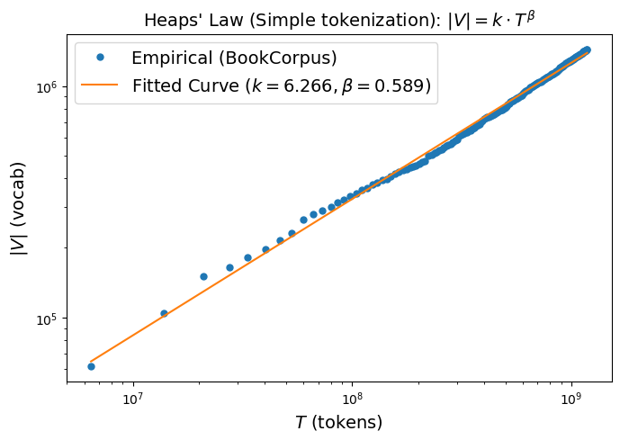

```python
import json
import numpy as np
import matplotlib.pyplot as plt
import matplotlib.ticker as mticker

def load_heaps_jsonl(log_path: str):
    Ns, Vs = [], []
    with open(log_path, "r", encoding="utf-8") as f:
        for line in f:
            r = json.loads(line)
            Ns.append(r["total_tokens"])
            Vs.append(r["vocab_size"])
    return np.array(Ns), np.array(Vs)

Ns, Vs = load_heaps_jsonl("assets/books1_wordcounts.heaps_log.jsonl")

# fit log |V| = log k + beta log N
beta, logk = np.polyfit(np.log(Ns), np.log(Vs), 1)
k = np.exp(logk)
print(f"Fit: |V| ≈ {k:.2f} * T^{beta:.3f}")


plt.figure(figsize=(7,5))

plt.loglog(Ns, Vs, marker="o", linestyle="none",
           markersize=5, label="Empirical (BookCorpus)")
Ns_line = np.linspace(Ns[0], Ns[-1], 200)
plt.loglog(Ns_line, k * (Ns_line ** beta), label=fr"Fitted Curve $(k={k:.3f},\beta=${beta:.3f})")
plt.xlabel("$T$ (tokens)", fontsize = 14)
plt.ylabel("$|V|$ (vocab)", fontsize = 14)
plt.title(r"Heaps' Law (Simple tokenization): $|V|=k \cdot T^{\beta}$", fontsize = 14)
plt.legend(fontsize = 14)
plt.tight_layout()
plt.show()
```

## 4. LLMs tokenization (Modern Way)

In general, there are two type of tokenizations

- **Top-down tokenization**: It defines a standard and implement rules to implement that kind of tokenization. It includes, for example, word tokenization, charater tokenization, and others.
- **Bottom-up tokenization**: It uses simple statistics of letter sequences to break up words into subword tokens. Subword tokenization (modern LLMs use this type!) belongs to this type.

In case of bottom-up tokenization, there are three standard way to do modern LLM tokenization:

- **BPE tokenization:** [Original BPE paper], [Adopted in GPT-2]
- **Wordpiece tokenization:** [Original Wordpiece paper], [Adopted in GNMT], [Adopted in BERT]
- **Unigram tokenization:** [Original Unigram paper], [Adopted in AlBERT], [Adopted in T5]

```python
import tiktoken
```

### 4.1 BPE tokenization

- **Explore trained tokenizer: tiktoken** Any trained tokenizer has two functions:
  - **encode**: it maps running text into token ids (integers)
  - **decode**: it maps token id back to each text token (strings)
- It has been adopted from all modern LLMs including ChatGPT, GPT-series, and many others.
- tiktoken uses a byte-level BPE. (The emoji like 🤗 could be encoded as multiple UTF-8 bytes.)

#### 4.1.1 explore tiktoken tokenizer

The [tiktoken tokenizer](https://github.com/openai/tiktoken).

```python
# Load cl100k_tokenizer (it was used by gpt-3.5-turbo family, gpt-4, and also gpt-4-turbo
# 加载 cl100k_tokenizer（它被 GPT-3.5-turbo 系列、GPT-4，以及 GPT-4-turbo 使用）
cl100k_tokenizer = tiktoken.get_encoding("cl100k_base")

text = "Don't you love 🤗 Transformers? We sure do."
token_ids = cl100k_tokenizer.encode(text)
token_strs = [cl100k_tokenizer.decode([tid]) for tid in token_ids]

print("ids:", token_ids)
print("tokens:", token_strs)
```

```
ids: [8161, 956, 499, 3021, 11410, 97, 245, 81632, 30, 1226, 2771, 656, 13]
tokens: ['Don', "'t", ' you', ' love', ' �', '�', '�', ' Transformers', '?', ' We', ' sure', ' do', '.']
```

- what you’re seeing (' �', '�', '�') is normal. Those are individual bytes / partial UTF-8 pieces that don’t form a valid standalone Unicode character when decoded one token at a time.
- Next, we explore o200k_base, which is the tokenizer (encoding) used by OpenAI’s newer “o-series” models, especially the GPT-4o family. If you call a model like gpt-4o / gpt-4o-mini, the tokenization is o200k_base.

```python
gpt35_tokenizer = tiktoken.get_encoding("o200k_base")

token_ids = gpt35_tokenizer.encode(text)
token_strs = [gpt35_tokenizer.decode([tid]) for tid in token_ids]

print("ids:", token_ids)
print("tokens:", token_strs)

# Count tokens by counting the length of the list returned by .encode().
def num_tokens_from_string(string: str, encoding_name: str) -> int:
    """Returns the number of tokens in a text string."""
    encoding = tiktoken.get_encoding(encoding_name)
    num_tokens = len(encoding.encode(string))
    return num_tokens
print("---")

text = "Don't you love 🤗 Transformers? We sure do."
print(f'\"{text}\" has been encoded into {num_tokens_from_string(text, "cl100k_base")} subwords')
print(f'\"{text}\" has been encoded into {num_tokens_from_string(text, "o200k_base")} subwords')
```

```
ids: [31559, 481, 3047, 93643, 245, 156303, 30, 1416, 3239, 621, 13]
tokens: ["Don't", ' you', ' love', ' �', '�', ' Transformers', '?', ' We', ' sure', ' do', '.']
---
"Don't you love 🤗 Transformers? We sure do." has been encoded into 13 subwords
"Don't you love 🤗 Transformers? We sure do." has been encoded into 11 subwords
```

- Note the tokens generated above is slightly different from ones generated by cl100k_base.

```python
# .decode() converts a list of token integers to a string.
encode_ids = [83, 1609, 5963, 374, 2294, 0, 11, 2025]
print(f'the decoded string is: \"{gpt35_tokenizer.decode(encode_ids)}\"')
```

```
the decoded string is: "turesറلás!,(t"
```

- Try a slightly long text.

```python
text = """
Chapters 5 to 8 teach the basics of 🤗 Datasets and 🤗 Tokenizers before diving into classic NLP tasks.\
By the end of this part, you will be able to tackle the most common NLP problems by yourself. \
By the end of this part, you will be ready to apply 🤗 Transformers to (almost) any machine \
learning problem! E=mc^2. f(x) = x^2+y^2, print('hello world!’) baojianzhou. asdasfasdgasdg
"""
token_ids = gpt35_tokenizer.encode(text)
token_strs = [gpt35_tokenizer.decode([tid]) for tid in token_ids]
print(token_ids)
print(token_strs)
```

```
[198, 1205, 54524, 220, 20, 316, 220, 23, 5113, 290, 42280, 328, 93643, 245, 415, 105003, 326, 93643, 245, 17951, 24223, 2254, 59474, 1511, 13686, 161231, 13638, 78061, 290, 1268, 328, 495, 997, 11, 481, 738, 413, 3741, 316, 37160, 290, 1645, 5355, 161231, 6840, 656, 6675, 13, 4534, 290, 1268, 328, …
['\n', 'Ch', 'apters', ' ', '5', ' to', ' ', '8', ' teach', ' the', ' basics', ' of', ' �', '�', ' D', 'atasets', ' and', ' �', '�', ' Token', 'izers', ' before', ' diving', ' into', ' classic', ' NLP', ' tasks', '.By', ' the', ' end', ' of', ' this', ' part', ',', ' you', ' will', ' be', ' able', '…
```

- **Limitations of general tokenizers**

**Generic tokenizers can split domain strings (genes/SMILES) in semantically harmful ways; we often need domain-specific tokenization (k-mers / specialized vocabularies) or character-level modeling.** Let us consider the following example

通用分词器可能会以破坏语义的方式拆分领域专用字符串（如基因序列、SMILES 字符串）；我们通常需要领域专用的分词方法（如 k‑mer 分词、专用词汇表）或字符级建模

```python
text = """acetylsalicylic acid, aspirin, Group of substances: organic Physical appearance: \
colorless needles crystals Empirical formula (Hill's system for organic substances): \
C9H8O4 Structural formula as text: CH3COOC6H4COOH,
the smiles format of it is CC(=O)OC1=CC=CC=C1C(O)=O."""

token_ids = gpt35_tokenizer.encode(text)
token_strs = [gpt35_tokenizer.decode([tid]) for tid in token_ids]
print(token_ids)
print(token_strs) # CC(=O)OC1=CC=CC=C1C(O)=O. should be a whole, but it is tokenized into small pieces.
```

```
[86583, 3643, 25396, 3869, 459, 18655, 11, 162142, 11, 7849, 328, 44166, 25, 19448, 45544, 16814, 25, 3089, 2695, 94833, 70994, 15601, 138477, 20690, 350, 154150, 885, 2420, 395, 19448, 44166, 3127, 363, 24, 39, 23, 46, 19, 131678, 20690, 472, 2201, 25, 10049, 18, 8310, 8695, 21, 39, 19, 8310, 45485…
['acet', 'yl', 'sal', 'icy', 'lic', ' acid', ',', ' aspirin', ',', ' Group', ' of', ' substances', ':', ' organic', ' Physical', ' appearance', ':', ' color', 'less', ' needles', ' crystals', ' Emp', 'irical', ' formula', ' (', 'Hill', "'s", ' system', ' for', ' organic', ' substances', '):', ' C', …
```

#### 4.1.2 train a BPE tokenizer using tokenizers

- **tokenizers is fast**

  It is extremely fast (both training and tokenization), thanks to the Rust implementation. Takes less than 20 seconds to tokenize a GB of text on a server's CPU.
- **Example of training BPE using tokenizers**

  We will use wikitext-103 to train a tokenizer
  - Start with all the characters present in the training corpus as tokens.
  - Identify the most common pair of tokens and merge it into one token.
  - Repeat until the vocabulary (e.g., the number of tokens) has reached the size we want.
- **Step 1: pretraining for tokenization learner (adding whitespace)**

```python
from datasets import load_dataset
from tokenizers import Tokenizer
from tokenizers.models import BPE
from tokenizers.trainers import BpeTrainer
from tokenizers.pre_tokenizers import Whitespace

# load wikitext-103
wiki103_ds = load_dataset("wikitext", "wikitext-103-raw-v1")  # train/validation/test

# Step 1: pre-training
tokenizer = Tokenizer(BPE(unk_token="[UNK]"))
tokenizer.pre_tokenizer = Whitespace()
```

- **Step 2: training (using BPE algorithm)**

```python
start_time = time.time()

# build tokenizer + trainer
trainer = BpeTrainer(
    vocab_size=30000,
    special_tokens=["[UNK]", "[PAD]", "[BOS]", "[EOS]", "[MASK]", "[CLS]", "[SEP]"]
)
# iterator over ALL splits
def batch_iterator(batch_size=1000):
    for split in ["train", "validation", "test"]:
        for i in range(0, len(wiki103_ds[split]), batch_size):
            yield wiki103_ds[split][i:i+batch_size]["text"]
tokenizer.train_from_iterator(batch_iterator(), trainer=trainer)
# It will take above 1 second
print(f"Total runtime of training tokenizer on wikitext-103: {time.time() - start_time:.3f} seconds")
```

```
Total runtime of training tokenizer on wikitext-103: 15.698 seconds
```

- **Step 3: save the tokenizer**

```python
# Step 3: save the trained tokenizer
tokenizer.save("assets/wikitext103-bpe.json")
```

```python
tokenizer = Tokenizer.from_file("assets/wikitext103-bpe.json")
output = tokenizer.encode("Hello, y'all! How are you 😁 ?")
print(output.tokens)
print(output.ids)
```

```
['Hello', ',', 'y', "'", 'all', '!', 'How', 'are', 'you', '[UNK]', '?']
[27255, 18, 95, 13, 5099, 7, 7963, 5114, 6220, 0, 37]
```

### 4.2 WordPiece tokenization

- **Step 1: normalization**

```python
# Step 1: normalization（文本标准化）, Normalization is, in a nutshell, a set of operations you apply to
# a raw string to make it less random or “cleaner”. Common operations include stripping
# whitespace, removing accented characters or lowercasing all text.

from tokenizers import normalizers
from tokenizers.normalizers import NFD, StripAccents
normalizer = normalizers.Sequence([NFD(), StripAccents()])

print(normalizer.normalize_str("Héllò hôw are ü?"))
tokenizer.normalizer = normalizer #把这个 文本标准化规则 加到 tokenizer 中。
```

```
Hello how are u?
```

- **Step 2: Pre-Tokenization**

```python
# Step 2: Pre-Tokenization, Pre-tokenization is the act of splitting a text into smaller
# objects that give an upper bound to what your tokens will be at the end of training.
# A good way to think of this is that the pre-tokenizer will split your text into “words”
# and then, your final tokens will be parts of those words. An easy way to pre-tokenize
# inputs is to split on spaces and punctuations, which is done by the pre_tokenizers.
from tokenizers.pre_tokenizers import Whitespace
pre_tokenizer = Whitespace()
pre_tokenizer.pre_tokenize_str("Hello! How are you? I'm fine, thank you.")
```

```
[('Hello', (0, 5)),
 ('!', (5, 6)),
 ('How', (7, 10)),
 ('are', (11, 14)),
 ('you', (15, 18)),
 ('?', (18, 19)),
 ('I', (20, 21)),
 ("'", (21, 22)),
 ('m', (22, 23)),
 ('fine', (24, 28)),
 (',', (28, 29)),
 ('thank', (30, 35)),
 ('you', (36, 39)),
 ('.', (39, 40))]
```

```python
from tokenizers import pre_tokenizers
from tokenizers.pre_tokenizers import Digits
pre_tokenizer = pre_tokenizers.Sequence([Whitespace(), Digits(individual_digits=True)])
pre_tokenizer.pre_tokenize_str("Call 911!")
```

```
[('Call', (0, 4)), ('9', (5, 6)), ('1', (6, 7)), ('1', (7, 8)), ('!', (8, 9))]
```

- **Step 3: Choose your model (WordPiece)**

Choose your tokenization algorithm.

- models.BPE
- models.Unigram
- models.WordLevel
- models.WordPiece
- **Step 4: Post-Processing**

Post-processing is the last step of the tokenization pipeline, to perform any additional transformation to the Encoding before it’s returned, like adding potential special tokens.

```python
#Post-processing = 给 tokenizer 输出加上模型需要的特殊 token。
from tokenizers.processors import TemplateProcessing
tokenizer.post_processor = TemplateProcessing(
    single="[CLS] $A [SEP]",
    pair="[CLS] $A [SEP] $B:1 [SEP]:1",
    special_tokens=[("[CLS]", 1), ("[SEP]", 2)],
)
```

```python
# BERT tokenization building

start_time = time.time()

#创建 WordPiece tokenizer
from transformers import AutoTokenizer
from tokenizers import Tokenizer
from tokenizers.models import WordPiece
bert_tokenizer = Tokenizer(WordPiece(unk_token="[UNK]"))

#Normalization（标准化）
from tokenizers import normalizers
from tokenizers.normalizers import NFD, Lowercase, StripAccents
bert_tokenizer.normalizer = normalizers.Sequence([NFD(), Lowercase(), StripAccents()]) #拆开字符，变小写，去掉重音符号

#Pre-tokenization（预分词）
from tokenizers.pre_tokenizers import Whitespace
bert_tokenizer.pre_tokenizer = Whitespace()

#Post-processing（后处理）
from tokenizers.processors import TemplateProcessing
bert_tokenizer.post_processor = TemplateProcessing(
    single="[CLS] $A [SEP]",
    pair="[CLS] $A [SEP] $B:1 [SEP]:1",
    special_tokens=[
        ("[CLS]", 1),
        ("[SEP]", 2),
    ],
)

# #Decoder（解码器）: 将 token ids 转回字符串
# from tokenizers.decoders import WordPiece as WordPieceDecoder
# bert_tokenizer.decoder = WordPieceDecoder(prefix="##")

#定义 WordPiece 训练器
from tokenizers.trainers import WordPieceTrainer
trainer = WordPieceTrainer(vocab_size=30522, special_tokens=["[UNK]", "[CLS]", "[SEP]", "[PAD]", "[MASK]"])

# iterator over ALL splits
def batch_iterator(batch_size=1000):
    for split in ["train", "validation", "test"]:
        for i in range(0, len(wiki103_ds[split]), batch_size):
            yield wiki103_ds[split][i:i+batch_size]["text"]
bert_tokenizer.train_from_iterator(batch_iterator(), trainer=trainer)
# It will take above 1 second
print(f"Total runtime of training tokenizer on wikitext-103: {time.time() - start_time:.3f} seconds")
bert_tokenizer.save("assets/wikitext103-bert.json")
```

```
Total runtime of training tokenizer on wikitext-103: 25.678 seconds
```

- **Step 5: Encoding and Decoding**

```python
output = bert_tokenizer.encode("Hello, y'all! How are you 😁 ?")
print(output.ids)
# [1, 5993, 919, 16, 67, 11, 1772, 5, 1972, 1700, 2358, 0, 35, 2]

# bert_tokenizer.decode([1, 5993, 919, 16, 67, 11, 1772, 5, 1972, 1700, 2358, 0, 35, 2])
bert_tokenizer.decode([1,27462,16, 67, 11, 7323, 5, 7510, 7268, 7989, 0, 35, 2])
# "Hello , y ' all ! How are you ?"
```

```
[1, 27462, 16, 67, 11, 7323, 5, 7510, 7268, 7989, 0, 35, 2]
```

```
"hello , y ' all ! how are you ?"
```

```python
output = bert_tokenizer.encode("Welcome to the 🤗 Tokenizers library.")
print(output.tokens)
# ["[CLS]", "welcome", "to", "the", "[UNK]", "tok", "##eni", "##zer", "##s", "library", ".", "[SEP]"]
bert_tokenizer.decode(output.ids)
# "welcome to the tok ##eni ##zer ##s library ."
```

```
['[CLS]', 'welcome', 'to', 'the', '[UNK]', 'tok', '##eni', '##zer', '##s', 'library', '.', '[SEP]']
```

```
'welcome to the tok ##eni ##zer ##s library .'
```

### 4.4 Huggingface pretrained tokenizers

PreTrainedTokenizer, PreTrainedTokenizerBase, AutoTokenizer

- https://github.com/huggingface/transformers/blob/main/src/transformers/tokenization_utils.py
- https://github.com/huggingface/transformers/blob/main/src/transformers/tokenization_utils_base.py
- https://github.com/huggingface/transformers/blob/main/src/transformers/tokenization_utils_fast.py
- Check tokenizers at https://github.com/huggingface/transformers/blob/main/setup.py
- If you want to train a tokenizer by yourself, then go to: https://github.com/huggingface/tokenizers
- A fast BPE tokenizer is also at: https://github.com/openai/tiktoken
- An implementation of sentencepiece is at: https://github.com/google/sentencepiece
- There are 3 most common methods for tokenization: https://github.com/huggingface/tokenizers/tree/main/tokenizers/src/models
- - BPE: https://aclanthology.org/P16-1162.pdf
  - Unigram: https://arxiv.org/pdf/1804.10959
  - WordPiece https://static.googleusercontent.com/media/research.google.com/en//pubs/archive/37842.pdf

```python
from transformers import Qwen2Tokenizer, Qwen2TokenizerFast
```

```python
tokenizer = Qwen2TokenizerFast.from_pretrained(pretrained_model_name_or_path="Qwen/Qwen-tokenizer")
text = "What is natural language processing? 🤗"
encoded = tokenizer(text, return_tensors="pt")
print("Input IDs:", encoded["input_ids"])
```

```
Input IDs: tensor([[ 3838,   374,  5810,  4128,  8692,    30, 11162,    97,   245]])
```

```python
print(tokenizer.tokenize(text))
```

```
['What', 'Ġis', 'Ġnatural', 'Ġlanguage', 'Ġprocessing', '?', 'ĠðŁ', '¤', 'Ĺ']
```

```python
from transformers import AutoTokenizer
# Load the tokenizer
tokenizer = AutoTokenizer.from_pretrained("deepseek-ai/DeepSeek-V3")
# Example: tokenize some text
text = "What is natural language processing? 🤗"
encoded = tokenizer(text, return_tensors="pt")
print("Input IDs:", encoded["input_ids"])
decoded = tokenizer.decode(encoded["input_ids"][0])
print("Decoded text:", decoded)
decoded = tokenizer.decode(encoded["input_ids"][0], skip_special_tokens=True)
print("Decoded with special text:", decoded)
```

[output not shown]

```
Input IDs: tensor([[ 3085,   278,    80,  4616,   578,  3101, 52448,    33]])
Decoded text: Whatisnaturallanguageprocessing?
Decoded with special text: Whatisnaturallanguageprocessing?
```

```python
vocab = tokenizer.get_vocab()
print("Vocab size (attribute):", tokenizer.vocab_size)
print("Vocab size (dict length):", len(vocab))
id_to_token = {id_: tok for tok, id_ in vocab.items()}
pairs = [[i, repr(id_to_token[i])]for i in range(20)] # show first 20 tokens
print(pairs)
```

```
Vocab size (attribute): 128000
Vocab size (dict length): 128815
[[0, "'<｜begin▁of▁sentence｜>'"], [1, "'<｜end▁of▁sentence｜>'"], [2, "'<｜▁pad▁｜>'"], [3, "'!'"], [4, '\'"\''], [5, "'#'"], [6, "'$'"], [7, "'%'"], [8, "'&'"], [9, '"\'"'], [10, "'('"], [11, "')'"], [12, "'*'"], [13, "'+'"], [14, "','"], [15, "'-'"], [16, "'.'"], [17, "'/'"], [18, "'0'"], [19, "'1'"]]
```

```python
from transformers import AutoTokenizer
tokenizer = AutoTokenizer.from_pretrained("Qwen/Qwen2.5-72B-Instruct")
text = "What is natural language processing? 🤗"
encoded = tokenizer(text, return_tensors="pt")
print("Input IDs:", encoded["input_ids"])
# Decode including special tokens
decoded = tokenizer.decode(encoded["input_ids"][0])
print("Decoded text:", decoded)
```

[output not shown]

[output not shown]

[output not shown]

[output not shown]

[output not shown]

```
Input IDs: tensor([[ 3838,   374,  5810,  4128,  8692,    30, 11162,    97,   245]])
Decoded text: What is natural language processing? 🤗
```

```python
from transformers import AutoTokenizer
# Download vocabulary from huggingface.co and cache.
tokenizer = AutoTokenizer.from_pretrained("google-bert/bert-base-uncased")
# Download vocabulary from huggingface.co (user-uploaded) and cache.
tokenizer = AutoTokenizer.from_pretrained("dbmdz/bert-base-german-cased")
# If vocabulary files are in a directory (e.g. tokenizer was saved using *save_pretrained('./test/saved_model/')*)
# tokenizer = AutoTokenizer.from_pretrained("./test/bert_saved_model/")
# Download vocabulary from huggingface.co and define model-specific arguments
tokenizer = AutoTokenizer.from_pretrained("FacebookAI/roberta-base", add_prefix_space=True)
```

[output not shown]

[output not shown]

[output not shown]

[output not shown]

[output not shown]

[output not shown]

[output not shown]

[output not shown]

[output not shown]

[output not shown]

[output not shown]

## 5. Minimum Edit Distance

### 5.1 Algorithm analysis

Assessing the similarity between two strings is essential in many NLP tasks. For spell correction, one must choose the most similar word to a misspelled input from a set of candidates. For example, if `graffe"` is the input, among the options `graf`, `graft`, `grail`, and `giraffe`, the task is to select the word closest to the input based on a certain criterion. Similarly, comparing a translated sentence to a reference translation helps evaluate the performance of translation models in machine translation. This process may involve calculating the minimum edit distance to determine the similarity of two sentences. This note gives a dynamic programming algorithm for MED.

**Definition (Minimum Edit Distance, MED).**  
Given two strings $X=[x_1,x_2,\ldots,x_n]$ and $Y=[y_1,y_2,\ldots,y_m]$, the minimum edit distance between $X$ and $Y$ is the minimum number of edit operations required to convert $X$ into $Y$.  
**Allowed edit operations:**

1. **Insertion:** add a character to $X$.
2. **Deletion:** remove a character from $X$.
3. **Substitution:** replace a character in $X$ with another character.

These operations are applied sequentially from left to right to obtain $Y$.

**Example.** Suppose $X=\texttt{INTENTION}$ and $Y=\texttt{EXECUTION}$. One possible process of transforming $X \rightarrow Y$ is:

**Step-by-step edits (one possible alignment):**

1. $\texttt{INTENTION} \;\xrightarrow{\text{Del}(\texttt{I})}\; \texttt{NTENTION}$
2. $\texttt{NTENTION} \;\xrightarrow{\text{Sub}(\texttt{N}\rightarrow\texttt{E})}\; \texttt{ETENTION}$
3. $\texttt{ETENTION} \;\xrightarrow{\text{Sub}(\texttt{T}\rightarrow\texttt{X})}\; \texttt{EXENTION}$
4. $\texttt{EXENTION} \;\xrightarrow{\text{Ins}(\texttt{C})}\; \texttt{EXECNTION}$
5. $\texttt{EXECNTION} \;\xrightarrow{\text{Sub}(\texttt{N}\rightarrow\texttt{U})}\; \texttt{EXECUTION} = Y$

We assume that **Ins** and **Del** each count as **1** operation, while **Sub** counts as **2** operations.  
Consequently, the total number of edit operations above is $1 + 2 + 2 + 1 + 2 = 8$.

Let $O_k=[o_1,o_2,\ldots,o_k]$ denote the sequence of operations transforming $X$ into $Y$, where each $o_i \in \{\text{Ins},\text{Del},\text{Sub}\}$.  
We call $O_k$ an alignment of $X$ into $Y$ (see the figure below).

[figure not shown]

- **Dynamic Programming for MED**

A naive approach would examine all possible edit sequences $O_k$ and choose the one with the minimal cost. However, this method has **exponential** time complexity. Instead, we break the problem into smaller subproblems and exploit **optimal substructure**.

**Problem setting.** For $i=\{0,1,\ldots,n\}$ and $j=\{0,1,\ldots,m\}$, let

- $X_i = [x_1, x_2, \ldots, x_i]$ be the prefix of $X$ of length $i$.
- $Y_j = [y_1, y_2, \ldots, y_j]$ be the prefix of $Y$ of length $j$.

By default, $X_0=\emptyset$ and $Y_0=\emptyset$. Define $D[i,j]$ as the **minimum edit distance** from $X_i \rightarrow Y_j$. Clearly, $D[n,m]$ is the MED of $X \rightarrow Y$. There are two base cases:

- $D[i,0]=i$ (delete all $i$ characters from $X_i$).
- $D[0,j]=j$ (insert all $j$ characters into $\emptyset$).

In the rest, we assume $i,j \ge 1$.

**Optimal substructure.** Let $O_k=[o_1,o_2,\ldots,o_k]$ be a minimum-cost sequence of operations that transforms $X_i \rightarrow Y_j$. Then $$ X_i = X_i^{0} \xrightarrow{o_1} X_i^1 \xrightarrow{o_2} X_i^2 \rightarrow \cdots \xrightarrow{o_{k-1}} X_i^{k-1} \xrightarrow{o_k} X_i^k= Y_j . $$ If we remove the last operation $o_k$, the remaining sequence $O_{k-1}=[o_1,o_2,\ldots,o_{k-1}]$ must be an optimal process for $X_i \rightarrow X_i^{k-1}$. Otherwise, suppose there exists another sequence $O'_{k-1}$ that transforms $X_i \rightarrow X_i^{k-1}$ with strictly smaller cost: $\operatorname{cost}(O'_{k-1}) < \operatorname{cost}(O_{k-1})$. Then combining $O'_{k-1}$ with the last operation $o_k$ would yield a sequence for $X_i \rightarrow Y_j$ with total cost strictly smaller than $\operatorname{cost}(O_k)$—a contradiction. This is the optimal substructure property.

Because operations proceed from the left of $X_i$ to the right, there are only **three** possibilities for the last operation $o_k$:

- **Case 1 (Deletion).** Delete $x_i$ from $X_i$.
  $$ D[i,j] = D[i-1,j] + \operatorname{Del}(x_i). $$
- **Case 2 (Insertion).** Insert $y_j$ into $Y_{j-1}$.
  $$ D[i,j] = D[i,j-1] + \operatorname{Ins}(y_j). $$
- **Case 3 (Substitution).** Substitute $x_i$ by $y_j$.
  $$ D[i,j] = D[i-1,j-1] + \operatorname{Sub}(x_i,y_j). $$

Therefore, MED for $X_i \rightarrow Y_j$ can be computed from the three subproblems $D[i-1,j]$, $D[i,j-1]$, and $D[i-1,j-1]$ by taking the minimum:

$$ D[i,j] = \min\begin{cases} D[i-1,j] + \operatorname{Del}(x_i),\\[2pt] D[i,j-1] + \operatorname{Ins}(y_j),\\[2pt] D[i-1,j-1] + \operatorname{Sub}(x_i,y_j). \end{cases} $$

This recurrence is the core of **dynamic programming** for MED. In the example above, we can compute the DP matrix $\mathbf{D}$ using this recurrence, as shown in the following tables. The above formula is called dynamic procedure or dynamic programming. Given the above-mentioned example, we can calculate matrix $\mathbf{D}$ using this dynamic procedure as shown in the following tables.

- **DP Table: Initialization vs. Final Result**

Initial stage: \(D[\cdot,\cdot]\)

$$ % --- paste your FIRST table here --- \begin{array}{l|l|l|l|l|l|l|l|l|l|l} {N} & {9} & & & & & & & & & \\ \hline {O} & {8} & & & & & & & & & \\ \hline {I} & {7} & & & & & & & & & \\ \hline {T} & {6} & & & & & & & & & \\ \hline {N} & {5} & & & & & & & & & \\ \hline {E} & {4} & & & & & & & & & \\ \hline {T} & {3} & & & & & & & & & \\ \hline {N} & {2} & & & & & & & & & \\ \hline {I} & {1} & & & & & & & & & \\ \hline \# & {0} & {1} & {2} & {3} & {4} & {5} & {6} & {7} & {8} & {9} \\ \hline & \# & {E} & {X} & {E} & {C} & {U} & {T} & {I} & {O} & {N} \end{array} $$

Final stage: \(D[n,m]=8\)

$$ % --- paste your SECOND table here --- \begin{array}{c|c|c|c|c|c|c|c|c|c|c} N & 9 & 8 & 9 & 10 & 11 & 12 & 11 & 10 & 9 & \color{red}{8} \\ \hline O & 8 & 7 & 8 & 9 & 10 & 11 & 10 & 9 & 8 & 9 \\ \hline I & 7 & 6 & 7 & 8 & 9 & 10 & 9 & 8 & 9 & 10 \\ \hline T & 6 & 5 & 6 & 7 & 8 & 9 & 8 & 9 & 10 & 11 \\ \hline N & 5 & 4 & 5 & 6 & 7 & 8 & 9 & 10 & 11 & 10 \\ \hline E & 4 & 3 & 4 & 5 & 6 & 7 & 8 & 9 & 10 & 9 \\ \hline T & 3 & 4 & 5 & 6 & 7 & 8 & 7 & 8 & 9 & 8 \\ \hline N & 2 & 3 & 4 & 5 & 6 & 7 & 8 & 7 & 8 & 7 \\ \hline I & 1 & 2 & 3 & 4 & 5 & 6 & 7 & 6 & 7 & 8 \\ \hline \# & 0 & 1 & 2 & 3 & 4 & 5 & 6 & 7 & 8 & 9 \\ \hline & \# & E & X & E & C & U & T & I & O & N \end{array} $$

**Remark.** We call the above method a **dynamic programming** method.

1. Try to prove or disprove the **uniqueness** of the optimal sequence of operations.
2. Can you find approximate solutions if $n$ and $m$ are large? (Hint: search for [approximate string matching](https://en.wikipedia.org/wiki/Approximate_string_matching).)

### 5.2 Algorithm implementation

```python
# define minimum edit distance algorithm via dynamic programming
def minimum_edit_distance(source, target):
    n = len(source)
    m = len(target)
    d_mat = np.zeros((n + 1, m + 1))
    for i in range(1, n + 1):
        d_mat[i, 0] = i
    for j in range(1, m + 1):
        d_mat[0, j] = j
    for i in range(1, n + 1):
        for j in range(1, m + 1):
            sub = 0 if source[i - 1] == target[j - 1] else 2
            del_ = d_mat[i - 1][j] + 1
            ins_ = d_mat[i][j - 1] + 1
            d_mat[i][j] = min(del_, ins_, d_mat[i - 1][j - 1] + sub)
    trace, align_source, align_target = backtrack_alignment(source, target, d_mat)
    return d_mat[n, m], trace, align_source, align_target

def backtrack_alignment(source, target, d_mat):
    align_source, align_target = [], []
    i, j = len(source), len(target)
    back_trace = [[i, j]]

    while (i, j) != (0, 0):
        # boundary cases first (avoid negative indexing)
        if i == 0:
            back_trace.append([i, j - 1])
            align_source = ["*"] + align_source
            align_target = [target[j - 1]] + align_target
            j -= 1
            continue
        if j == 0:
            back_trace.append([i - 1, j])
            align_source = [source[i - 1]] + align_source
            align_target = ["*"] + align_target
            i -= 1
            continue

        sub_cost = 0 if source[i - 1] == target[j - 1] else 2

        # prefer substitution/match when optimal (your tie-break rule)
        if d_mat[i, j] == d_mat[i - 1, j - 1] + sub_cost:
            back_trace.append([i - 1, j - 1])
            align_source = [source[i - 1]] + align_source
            align_target = [target[j - 1]] + align_target
            i, j = i - 1, j - 1

        # deletion
        elif d_mat[i, j] == d_mat[i - 1, j] + 1:
            back_trace.append([i - 1, j])
            align_source = [source[i - 1]] + align_source
            align_target = ["*"] + align_target
            i -= 1

        # insertion
        else:
            back_trace.append([i, j - 1])
            align_source = ["*"] + align_source
            align_target = [target[j - 1]] + align_target
            j -= 1

    return back_trace, align_source, align_target

# test the minimum edit distance
def test_med(source, target):
    med, trace, align_source, align_target = minimum_edit_distance(source, target)
    print(f"input source: {source} and target: {target}")
    print(f"med: {med}")
    print(f"trace: {trace}")
    print(f"aligned source: {align_source}")
    print(f"aligned target: {align_target}")
```

```python
test_med(source="INTENTION", target="EXECUTION")
```

```
input source: INTENTION and target: EXECUTION
med: 8.0
trace: [[9, 9], [8, 8], [7, 7], [6, 6], [5, 5], [4, 4], [4, 3], [3, 2], [2, 1], [1, 0], [0, 0]]
aligned source: ['I', 'N', 'T', 'E', '*', 'N', 'T', 'I', 'O', 'N']
aligned target: ['*', 'E', 'X', 'E', 'C', 'U', 'T', 'I', 'O', 'N']
```

```python
test_med(source="AGGCTATCACCTGACCTCCAGGCCGATGCCC", target="TAGCTATCACGACCGCGGTCGATTTGCCCGAC")
```

```
input source: AGGCTATCACCTGACCTCCAGGCCGATGCCC and target: TAGCTATCACGACCGCGGTCGATTTGCCCGAC
med: 15.0
trace: [[31, 32], [30, 31], [30, 30], [30, 29], [29, 28], [28, 27], [28, 26], [27, 25], [26, 24], [26, 23], [26, 22], [25, 21], [24, 20], [23, 19], [22, 18], [21, 17], [20, 16], [19, 16], [18, 15], [17, 14], [16, 14], [15, 13], [14, 12], [13, 11], [12, 10], [11, 10], [10, 9], [9, 9], [8, 8], [7, 7],…
aligned source: ['*', 'A', 'G', 'G', 'C', 'T', 'A', 'T', 'C', 'A', 'C', 'C', 'T', 'G', 'A', 'C', 'C', 'T', 'C', 'C', 'A', 'G', 'G', 'C', 'C', 'G', 'A', '*', '*', 'T', 'G', '*', 'C', 'C', '*', '*', 'C']
aligned target: ['T', 'A', '*', 'G', 'C', 'T', 'A', 'T', 'C', 'A', '*', 'C', '*', 'G', 'A', 'C', 'C', '*', 'G', 'C', '*', 'G', 'G', 'T', 'C', 'G', 'A', 'T', 'T', 'T', 'G', 'C', 'C', 'C', 'G', 'A', 'C']
```

## 6. Submit your work

```python
# Finally, you all done! Please submit your jupyter notebook via elearning!

your_chinese_name = "姚程缤" # put your chinese name here
your_student_id = "25210980125" # put your student id here

jnk_end_time = time.time()
total = jnk_end_time - jnk_start_time
h, rem = divmod(int(total), 3600)
m, s = divmod(rem, 60)

print(f"Total runtime: {h} h {m} min {s} s")
print(f"I am {your_chinese_name}:{your_student_id}, I am doing a great job!")
```

```
Total runtime: 5 h 33 min 53 s
I am 姚程缤:25210980125, I am doing a great job!
```

- **Run the following command and submit the pdf version accordingly**

```python
!pip uninstall jupyter_contrib_nbextensions -y
```

```
Found existing installation: jupyter_contrib_nbextensions 0.7.0
Uninstalling jupyter_contrib_nbextensions-0.7.0:
  Successfully uninstalled jupyter_contrib_nbextensions-0.7.0
```

```python
!jupyter nbconvert lecture-01-exercise-tokenization-25210980125-姚程缤.ipynb --to html --template classic --embed-images
```

```
[NbConvertApp] Converting notebook lecture-01-exercise-tokenization-25210980125-姚程缤.ipynb to html
[NbConvertApp] WARNING | Alternative text is missing on 5 image(s).
[NbConvertApp] Writing 13750645 bytes to lecture-01-exercise-tokenization-25210980125-姚程缤.html
```

## 7. Useful commands

```
jupyter nbconvert lecture-01-exercise-tokenization.ipynb --to html --template classic --embed-images
```

- **2. Save your env from installed history**

```
conda env export --from-history > your-environment.yml
```

If you do not want to have prefix in the end of yml file, you can try to remove the prefix line by using:

[output not shown]

- **3. Start uvicorn server**

```
uvicorn test_sd_server:app --host 127.0.0.1 --port 5055
```